# A Composition Benchmark for UI Claims Intensity

How Much of Low UI Coverage Is About Who Is Unemployed?

Author

Aryan Safi

Published

April 2, 2026

```r
library(tidyverse)
library(here)
library(fredr)
library(ggsci)
library(scales)
library(gt)
library(lubridate)
library(ipumsr)
library(patchwork)
library(fixest)
library(modelsummary)
library(prophet)

here::i_am("ui_composition_benchmark.qmd")

fredr_set_key("ccd350785a210a7653a20d02ce92d83a")

# ── Theme ────────────────────────────────────────────────────────────────
theme_report <- theme_minimal(base_size = 11, base_family = "sans") +
  theme(
    plot.title = element_text(face = "bold", size = 13),
    plot.subtitle = element_text(color = "grey50", size = 9),
    plot.caption = element_text(color = "grey60", size = 7, hjust = 0),
    panel.grid.minor = element_blank(),
    panel.grid.major.x = element_blank(),
    axis.title = element_text(size = 9, color = "grey40"),
    axis.text = element_text(size = 8, color = "grey50"),
    legend.position = "top",
    legend.text = element_text(size = 8),
    legend.title = element_blank()
  )

theme_set(theme_report)

# ── Palettes ─────────────────────────────────────────────────────────────
cause_cols <- pal_jco()(6)
names(cause_cols) <- c("Temporary Layoff", "Permanent Job Losers",
                       "Completed Temp Job", "Job Leavers",
                       "Reentrants", "New Entrants")

group_cols <- c("Job Separations" = "#0073C2", "Labor Force Entry" = "#EFC000")

# ── NBER recession dates (post-1994) ────────────────────────────────────
recessions <- tibble(
  start = as.Date(c("2001-03-01", "2007-12-01", "2020-02-01")),
  end   = as.Date(c("2001-11-01", "2009-06-01", "2020-04-01"))
)

add_recessions <- function(p, alpha = 0.08) {
  p + annotate("rect",
    xmin = recessions$start, xmax = recessions$end,
    ymin = -Inf, ymax = Inf,
    fill = "grey40", alpha = alpha
  )
}

# ── State metadata ───────────────────────────────────────────────────────
state_meta <- tibble(
  state = state.name,
  abb = state.abb,
  fips = c(
    "01", "02", "04", "05", "06", "08", "09", "10", "12", "13",
    "15", "16", "17", "18", "19", "20", "21", "22", "23", "24",
    "25", "26", "27", "28", "29", "30", "31", "32", "33", "34",
    "35", "36", "37", "38", "39", "40", "41", "42", "44", "45",
    "46", "47", "48", "49", "50", "51", "53", "54", "55", "56"
  )
) |>
  arrange(state)

# ── FRED retry helper ────────────────────────────────────────────────────
fredr_retry <- function(series_id, ..., max_tries = 5, wait_secs = 3) {
  for (i in seq_len(max_tries)) {
    result <- tryCatch(fredr(series_id, ...), error = function(e) e)
    if (!inherits(result, "error")) return(result)
    if (i < max_tries) Sys.sleep(wait_secs)
  }
  stop("FRED API failed after ", max_tries, " attempts for ", series_id,
       ": ", conditionMessage(result))
}

# ── Regression table helper ──────────────────────────────────────────────
msummary_styled <- function(models, title, notes) {
  msummary(
    models,
    stars = c("*" = 0.10, "**" = 0.05, "***" = 0.01),
    gof_map = c("nobs", "r.squared", "adj.r.squared", "within.r.squared"),
    title = title,
    notes = notes,
    output = "gt"
  ) |>
    tab_options(table.font.size = px(11))
}
```

# Abstract

The share of unemployed Americans receiving unemployment insurance benefits has fallen sharply over five decades. Yet the headline unemployment rate—the most common benchmark—includes new entrants, reentrants, and voluntary leavers whom UI was never designed to cover. This paper constructs a reduced-form, composition-based benchmark for UI claims intensity. Using FRED administrative data on state-level UI claims and CPS microdata on unemployment composition, I estimate the level of claims intensity (continued claims and initial claims per covered employment) historically associated with a given mix of unemployment by reason. The composition of unemployment accounts for a meaningful share of cross-state, over-time variation in claims intensity, but a substantial residual gap persists—particularly in recent years. That residual—the portion of claims intensity not captured by the composition benchmark—is where non-composition factors such as administrative burden, employer contestation, benefit generosity, information frictions, and demographic disparities may operate. The contribution is not to discover that job losers are more UI-relevant than new entrants; the literature already knows this. Rather, the paper quantifies how much reduced-form explanatory leverage the composition channel provides and how large the unexplained residual is.

# 1. Introduction

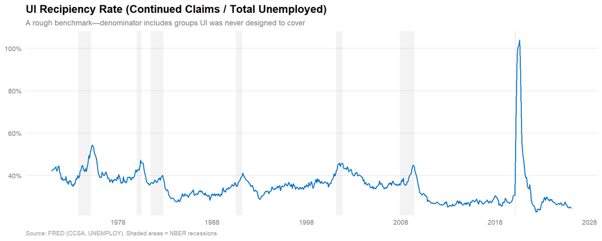

Figure 1: UI recipiency rate: continued claims as a share of total unemployed, 1971–present. Monthly data; continued claims (CCSA, weekly SA) averaged within each month and divided by total unemployed (UNEMPLOY, in thousands, SA). Gray bands denote NBER recessions.

```r
recipiency_raw <- bind_rows(

  fredr_retry("CCSA",     observation_start = as.Date("1971-01-01")) |>
    transmute(date, series = "CCSA",     value),
  fredr_retry("UNEMPLOY", observation_start = as.Date("1971-01-01")) |>
    transmute(date, series = "UNEMPLOY", value)
)

recipiency_df <- recipiency_raw |>
  mutate(month = floor_date(date, "month")) |>
  summarise(
    .by = c(series, month),
    value = mean(value, na.rm = TRUE)
  ) |>
  pivot_wider(names_from = series, values_from = value) |>
  filter(!is.na(CCSA), !is.na(UNEMPLOY), UNEMPLOY > 0) |>
  mutate(recipiency_rate = CCSA / (UNEMPLOY * 1000))

recessions_long <- tibble(
  start = as.Date(c("1973-11-01", "1980-01-01", "1981-07-01",
                     "1990-07-01", "2001-03-01", "2007-12-01", "2020-02-01")),
  end   = as.Date(c("1975-03-01", "1980-07-01", "1982-11-01",
                     "1991-03-01", "2001-11-01", "2009-06-01", "2020-04-01"))
)

p_recip <- ggplot(recipiency_df, aes(month, recipiency_rate)) +
  annotate("rect",
    xmin = recessions_long$start, xmax = recessions_long$end,
    ymin = -Inf, ymax = Inf,
    fill = "grey40", alpha = 0.08
  ) +
  geom_line(color = "#0073C2", linewidth = 0.6) +
  scale_y_continuous(labels = percent_format(accuracy = 1),
                     expand = expansion(mult = c(0.02, 0.05))) +
  scale_x_date(date_breaks = "10 years", date_labels = "%Y") +
  labs(
    title = "UI Recipiency Rate (Continued Claims / Total Unemployed)",
    subtitle = "A rough benchmark—denominator includes groups UI was never designed to cover",
    y = NULL, x = NULL,
    caption = "Source: FRED (CCSA, UNEMPLOY). Shaded areas = NBER recessions."
  )

p_recip
```

UI was originally designed for a narrower insured population: workers with sufficient prior earnings who lost jobs through no fault of their own. The six BLS reason-for-unemployment categories—temporary layoff, permanent job loss, completed temporary job, voluntary quit, reentry to the labor force, and new entry—proxy distance from that original insured population (Table 1). New entrants have no prior work history. Reentrants may have been out of the labor force long enough to exhaust or never establish eligibility. Job leavers are typically disqualified. Only job losers and temporary layoffs are squarely within the program’s intended reach.

```r
tibble(
  Category = c("Temporary Layoff", "Permanent Job Losers", "Completed Temp Job",
               "Job Leavers", "Reentrants", "New Entrants"),
  WHYUNEMP = 1:6,
  `BLS Definition` = c(
    "Given a return date or expects recall within 6 months",
    "Permanently separated---position eliminated, fired, or employer closed",
    "Temporary job or assignment has ended",
    "Voluntarily quit and now actively searching",
    "Previously held a job, left the labor force, now returned to searching",
    "Never held a job; actively looking for first one"
  ),
  `Two-Group` = c(rep("Job Separations", 4), rep("Labor Force Entry", 2))
) |>
  gt() |>
  tab_options(
    table.font.size = px(11),
    column_labels.font.weight = "bold",
    column_labels.background.color = "#2c3e50"
  ) |>
  tab_style(
    style = cell_text(color = "white"),
    locations = cells_column_labels()
  ) |>
  tab_style(
    style = cell_fill(color = "#dce8f5"),
    locations = cells_body(rows = `Two-Group` == "Job Separations")
  ) |>
  tab_style(
    style = cell_fill(color = "#fef3d0"),
    locations = cells_body(rows = `Two-Group` == "Labor Force Entry")
  )
```

Table 1: BLS reason-for-unemployment categories (CPS WHYUNEMP). The six categories are grouped into Job Separations (workers who previously held a job and left or lost it) and Labor Force Entry (workers entering or returning to the labor force).

| Category | WHYUNEMP | BLS Definition | Two-Group |
| --- | --- | --- | --- |
| Temporary Layoff | 1 | Given a return date or expects recall within 6 months | Job Separations |
| Permanent Job Losers | 2 | Permanently separated---position eliminated, fired, or employer closed | Job Separations |
| Completed Temp Job | 3 | Temporary job or assignment has ended | Job Separations |
| Job Leavers | 4 | Voluntarily quit and now actively searching | Job Separations |
| Reentrants | 5 | Previously held a job, left the labor force, now returned to searching | Labor Force Entry |
| New Entrants | 6 | Never held a job; actively looking for first one | Labor Force Entry |

If the composition of unemployment shifts toward groups with weaker UI attachment—more new entrants, more reentrants, fewer permanent job losers—then the level of aggregate claims intensity historically associated with that unemployment mix will be lower. The empirical question is how much of the observed variation in UI claims intensity can be accounted for by the realized composition of unemployment under this reduced-form relationship, and how much remains as an unexplained residual.

This paper constructs a composition-based benchmark for UI claims intensity. Using national FRED time series and a state-year panel merging FRED administrative claims data with CPS-based unemployment composition, I estimate the reduced-form mapping from by-cause unemployment shares to claims intensity. The gap between observed and benchmark-predicted intensity quantifies the residual not accounted for by unemployment composition—the space where institutional, administrative, and behavioral factors may operate.

The standard recipiency rate and the claims-intensity measures used here differ primarily in denominator choice rather than underlying substance. Let $B_t$ denote UI beneficiaries, $U_t$ total unemployment, and $CE_t$ covered employment. Then claims intensity can be written as $B_t / CE_t = (B_t / U_t) \times (U_t / CE_t)$. This identity clarifies the relationship between the two traditions: the recipiency literature focuses on $B_t / U_t$, or UI receipt among the unemployed, whereas CC/CE and IC/CE incorporate both receipt behavior and the scale of unemployment relative to the covered employment base. I use CC/CE and IC/CE because they are administratively grounded measures of aggregate UI caseload pressure, while unemployment composition is intended to capture how the claimant-relevant mix of the unemployed shifts over time. In that sense, the exercise here is not a pure model of recipiency conditional on unemployment, but a model of aggregate claims intensity in which recipiency-type composition effects are embedded within a covered-employment denominator.

The paper proceeds as follows. Section 2 reviews the relevant literature. Section 3 introduces a simple conceptual framework linking unemployment composition to expected claims intensity. Section 4 describes changes in the composition of unemployment over time. Section 5 describes the data. Section 6 prepares the claims and composition data. Section 7 presents each empirical exercise—specification, estimation, and results—in sequence. Section 8 discusses interpretation. Section 9 concludes.

# 2. Literature Review

## 2.1 Measurement

Conclusions about the health of the UI system depend critically on the denominator. Wandner and Stengle (1997) developed six alternative recipiency measures and showed that the standard rate (beneficiaries divided by all unemployed) is arguably misleading because the denominator includes groups UI was never designed to cover. Their most restrictive measure—all-program weeks claimed divided by job losers unemployed fewer than 27 weeks—showed that UI covered more than four-fifths of short-term job losers, a far more favorable picture than the standard 25–30% suggests.

Wittenburg et al. (1999) produced the definitive DOL meta-review, critically assessing prior studies and finding large differences in estimated effects across studies due to methodological variation. The present paper follows this tradition by being explicit about the denominator: covered employment, not total unemployment.

## 2.2 The Secular Decline

Burtless (1983) first documented the puzzle, finding that roughly 78% of the unemployed received UI in 1975 but only 45% did in 1982. Legislative changes explained about 60% of the decline. Blank and Card (1991) produced the most cited contribution: using PSID microdata matched with state eligibility rules, they showed that the fraction eligible for UI remained roughly constant over 1977–1987 and the entire decline was driven by falling take-up among eligibles. Anderson and Meyer (1997) resolved much of the remaining puzzle by showing that federal income taxation of benefits—phased in from 1978 to 1987—could account for most of the previously unexplained decline.

More recently, O’Leary et al. (2024) found the continued decline stems largely from changes in the industrial and occupational mix of employment interacting with UI program features. The Council of Economic Advisers (2024) reported that state differences in potential eligibility explain only 11% of recipiency rate variation, while most variation stems from other state policy and administrative choices.

## 2.3 Employer-Side and Institutional Explanations

Lachowska, Sorkin, and Woodbury (2025) introduced an employer-side perspective using two-way fixed effects models on Washington State administrative records. They found substantial firm effects on both claiming and appeals, with a strong negative correlation: firms that appeal more have lower claim rates. Their most striking finding is that the dominant targeting error is eligible non-claiming (28% of eligibles), not ineligible receipt (5%).

Budd and McCall (1997) showed that union blue-collar workers were 23% more likely to receive UI, consistent with an information and facilitation role. Auray and Fuller (2020) estimated that firm challenges account for 41% of total UI collection costs and that eliminating all challenges would raise take-up by 5.1 percentage points.

Ebenstein and Stange (2010) exploited the staggered introduction of telephone and Internet-based filing across states and found no appreciable impact on take-up, suggesting the barriers run deeper than transaction costs.

## 2.4 Racial and Demographic Disparities

Kuka and Stuart (2025) provided the most rigorous evidence on racial gaps: Black individuals who separate from a job are 30% less likely to receive UI and receive 46% fewer total benefits than White individuals, a gap stable over nearly 30 years. This gap stems primarily from lower take-up among eligible individuals, not eligibility differences. Skandalis, Marinescu, and Massenkoff (2022) showed that state rules alone create an 8.4% racial gap in entitlements because Black claimants disproportionately reside in less generous states.

## 2.5 Positioning This Paper

The literature already knows that job losers are more UI-relevant than new entrants or reentrants. What it has not systematically done is quantify the *explanatory power* of the by-cause composition channel for aggregate claims intensity in a panel setting and characterize the size and evolution of the residual gap. That is the contribution here. This paper is a composition-based benchmark, not the discovery of the composition idea. It occupies the space between the measurement papers (which define the right denominator) and the mechanism papers (which identify specific barriers to access).

# 3. Conceptual Framework

The central link between unemployment composition and UI claims intensity can be expressed in a simple decomposition. Let $y_{st}$ denote a claims-intensity measure (e.g., continued claims per covered employment) in state $s$ at time $t$, and let $s_{cst}$ denote the share of unemployment in state $s$ at time $t$ accounted for by cause $c$. Then:

$$y_{st} = \sum_{c} s_{cst} \cdot \lambda_c + \varepsilon_{st}
\tag{1}$$

where $\lambda_c$ is the reduced-form loading of cause $c$ on claims intensity and $\varepsilon_{st}$ is a residual not accounted for by composition. The composition-predicted component $\hat{y}_{st} = \sum_c s_{cst} \cdot \hat{\lambda}_c$ is a benchmark: the level of claims intensity historically associated with a given unemployment mix. I do not interpret the fitted values as the causal effect of unemployment composition on claims intensity. Instead, they represent a reduced-form benchmark for the level of claims intensity that the historical relationship in the data would predict given the realized composition of unemployment.

This benchmark is informative even though unemployment composition is not exogenous, because it summarizes an empirical regularity rather than identifying a pure causal channel. The by-cause shares are not randomly assigned treatments; they are jointly shaped by the same labor-market and policy shocks that affect claims intensity. The $\hat{\lambda}_c$ are therefore reduced-form loadings, not structural parameters. If the share of new entrants rises and new entrants have low $\hat{\lambda}$, benchmark-predicted intensity falls—but this need not reflect a mechanical compositional effect in isolation from the broader shock environment.

The residual $\varepsilon_{st}$ absorbs everything else:

- Administrative burden and hassle costs
- Employer contestation and experience-rated deterrence
- Benefit generosity and replacement rates
- State eligibility rules and policy design
- Information frictions and stigma
- Demographic disparities in access conditional on cause

The gap between observed and benchmark-predicted claims intensity, $y_{st} - \hat{y}_{st}$, is the portion not accounted for by unemployment composition under the historical reduced-form relationship. The empirical exercise estimates Equation 1 using a state-panel regression with fixed effects, then examines the size and time path of this residual.

# 4. Descriptive Background: Composition of Unemployment

This section documents how unemployment composition by reason has changed over time, emphasizing the shifts most relevant to UI claims intensity.

```r
# ── Pull all series from FRED ────────────────────────────────────────────
series_ids_6 <- c(
  "LNS13023653",   # On Temporary Layoff
  "LNS13026638",   # Permanent Job Losers
  "LNS13026637",   # Completed Temporary Job
  "LNS13023705",   # Job Leavers
  "LNS13023557",   # Reentrants
  "LNS13023569",   # New Entrants
  "UNEMPLOY",       # Total Unemployed
  "CLF16OV"         # Civilian Labor Force
)
series_names_6 <- c("Temporary Layoff", "Permanent Job Losers", "Completed Temp Job",
                     "Job Leavers", "Reentrants", "New Entrants", "Total", "CLF")

raw6 <- map2_dfr(series_ids_6, series_names_6, \(id, nm) {
  fredr(
    series_id = id,
    observation_start = as.Date("1994-01-01"),
    observation_end   = Sys.Date()
  ) |>
    transmute(date, series = nm, value)
})

cause_order <- c("Temporary Layoff", "Permanent Job Losers", "Completed Temp Job",
                 "Job Leavers", "Reentrants", "New Entrants")

df6 <- raw6 |>
  pivot_wider(names_from = series, values_from = value) |>
  drop_na() |>
  mutate(
    across(all_of(cause_order),
           \(x) x / CLF * 100,
           .names = "{.col}_rate"),
    urate = Total / CLF * 100
  )

df6_long <- df6 |>
  select(date, ends_with("_rate")) |>
  pivot_longer(-date, names_to = "cause", values_to = "rate") |>
  mutate(
    cause = str_remove(cause, "_rate"),
    cause = factor(cause, levels = cause_order)
  )

group_order <- c("Job Separations", "Labor Force Entry")

df2 <- df6 |>
  mutate(
    `Job Separations` = `Temporary Layoff` + `Permanent Job Losers` +
                         `Completed Temp Job` + `Job Leavers`,
    `Labor Force Entry` = Reentrants + `New Entrants`,
    `Job Separations_rate` = `Job Separations` / CLF * 100,
    `Labor Force Entry_rate` = `Labor Force Entry` / CLF * 100
  )

df2_long <- df2 |>
  select(date, `Job Separations_rate`, `Labor Force Entry_rate`) |>
  pivot_longer(-date, names_to = "group", values_to = "rate") |>
  mutate(
    group = str_remove(group, "_rate"),
    group = factor(group, levels = group_order)
  )
```

## 4.1 Unemployment Rate by Cause

The stacked bars below show each cause’s contribution to the headline unemployment rate since 1994. Job separations dominate cyclical variation, while labor force entry contributes a relatively stable base.

**Six-Way**

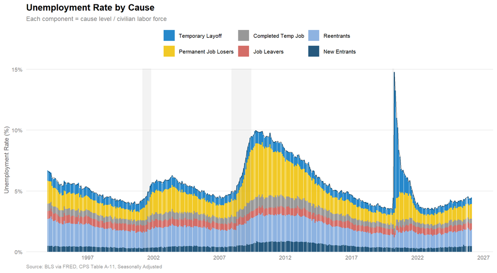

Figure 2: Unemployment rate decomposed by cause. Bars stack to total unemployment rate.

```r
p_cause <- df6_long |>
  ggplot(aes(x = date, y = rate, fill = cause)) +
  geom_col(alpha = 0.85, width = 28, position = "stack") +
  geom_line(
    data = df6, aes(x = date, y = urate, fill = NULL),
    color = "black", linewidth = 0.4, alpha = 0.5
  ) +
  scale_fill_manual(values = cause_cols) +
  scale_y_continuous(labels = \(x) paste0(x, "%"),
                     expand = expansion(mult = c(0, 0.02))) +
  scale_x_date(date_breaks = "5 years", date_labels = "%Y") +
  labs(
    title = "Unemployment Rate by Cause",
    subtitle = "Each component = cause level / civilian labor force",
    y = "Unemployment Rate (%)", x = NULL,
    caption = "Source: BLS via FRED, CPS Table A-11, Seasonally Adjusted"
  )

add_recessions(p_cause)
```

**Two-Group**

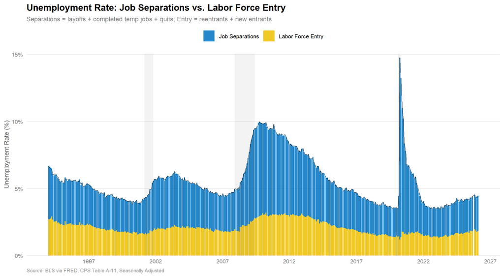

Figure 3: Unemployment rate decomposed into job separations vs. labor force entry.

```r
p_cause2 <- df2_long |>
  ggplot(aes(x = date, y = rate, fill = group)) +
  geom_col(alpha = 0.85, width = 28, position = "stack") +
  geom_line(
    data = df2, aes(x = date, y = urate, fill = NULL),
    color = "black", linewidth = 0.4, alpha = 0.5
  ) +
  scale_fill_manual(values = group_cols) +
  scale_y_continuous(labels = \(x) paste0(x, "%"),
                     expand = expansion(mult = c(0, 0.02))) +
  scale_x_date(date_breaks = "5 years", date_labels = "%Y") +
  labs(
    title = "Unemployment Rate: Job Separations vs. Labor Force Entry",
    subtitle = "Separations = layoffs + completed temp jobs + quits; Entry = reentrants + new entrants",
    y = "Unemployment Rate (%)", x = NULL,
    caption = "Source: BLS via FRED, CPS Table A-11, Seasonally Adjusted"
  )

add_recessions(p_cause2)
```

## 4.2 Year-Over-Year Changes

```r
df6_chg <- df6 |>
  arrange(date) |>
  mutate(
    across(all_of(paste0(cause_order, "_rate")),
           \(x) x - lag(x, 12),
           .names = "{.col}_chg"),
    urate_chg = urate - lag(urate, 12)
  ) |>
  filter(!is.na(urate_chg))

df6_chg_long <- df6_chg |>
  select(date, ends_with("_rate_chg")) |>
  pivot_longer(-date, names_to = "cause", values_to = "chg") |>
  mutate(
    cause = str_remove(cause, "_rate_chg"),
    cause = factor(cause, levels = cause_order)
  )
```

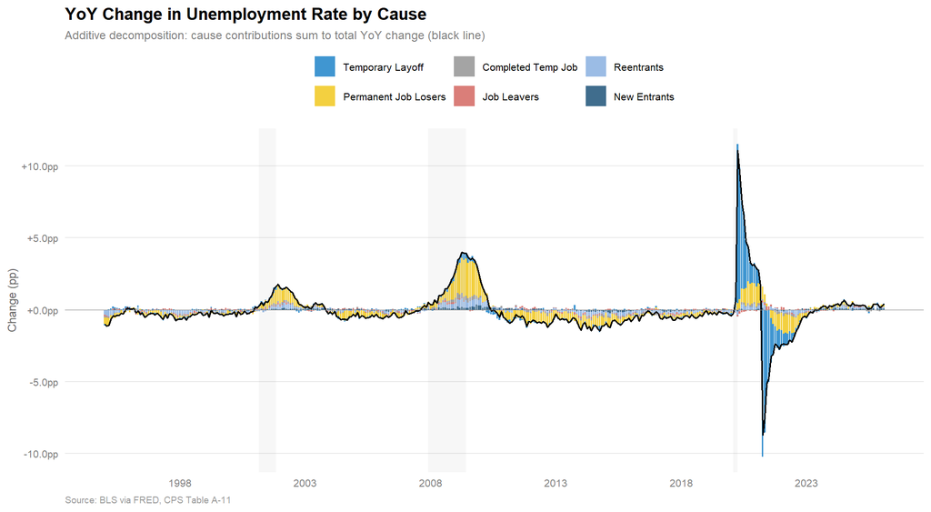

Figure 4: Year-over-year change in unemployment rate decomposed by cause.

```r
p_cause_chg <- df6_chg_long |>
  ggplot(aes(x = date, y = chg, fill = cause)) +
  geom_col(alpha = 0.75, width = 25) +
  geom_line(
    data = df6_chg, aes(x = date, y = urate_chg, fill = NULL),
    color = "black", linewidth = 0.6
  ) +
  geom_hline(yintercept = 0, color = "grey60", linewidth = 0.3) +
  scale_fill_manual(values = cause_cols) +
  scale_y_continuous(labels = \(x) paste0(sprintf("%+.1f", x), "pp")) +
  scale_x_date(date_breaks = "5 years", date_labels = "%Y") +
  labs(
    title = "YoY Change in Unemployment Rate by Cause",
    subtitle = "Additive decomposition: cause contributions sum to total YoY change (black line)",
    y = "Change (pp)", x = NULL,
    caption = "Source: BLS via FRED, CPS Table A-11"
  )

add_recessions(p_cause_chg, alpha = 0.05)
```

## 4.3 Composition Shares Over Time

For UI claims intensity, the relevant object is not the rate contribution of each cause but its *share* of total unemployment. A rising share of new entrants or reentrants means a larger fraction of the unemployed pool falls outside the traditional insured population.

```r
df6_shares <- df6 |>
  mutate(
    component_sum = `Temporary Layoff` + `Permanent Job Losers` + `Completed Temp Job` +
                    `Job Leavers` + Reentrants + `New Entrants`,
    across(all_of(cause_order),
           \(x) x / component_sum * 100,
           .names = "{.col}_share")
  ) |>
  select(date, ends_with("_share")) |>
  pivot_longer(-date, names_to = "cause", values_to = "share") |>
  mutate(
    cause = str_remove(cause, "_share"),
    cause = factor(cause, levels = cause_order)
  )
```

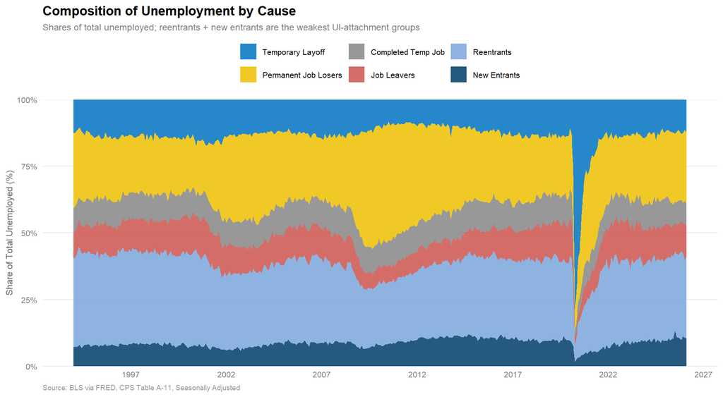

Figure 5: Composition of unemployment by cause (shares of total unemployed). Labor force entrants (reentrants + new entrants) comprise 30–45% of the unemployed in non-recessionary periods.

```r
ggplot(df6_shares, aes(x = date, y = share, fill = cause)) +
  geom_area(alpha = 0.85, position = "stack") +
  scale_fill_manual(values = cause_cols) +
  scale_y_continuous(labels = \(x) paste0(x, "%"),
                     expand = expansion(mult = c(0, 0))) +
  scale_x_date(date_breaks = "5 years", date_labels = "%Y") +
  labs(
    title = "Composition of Unemployment by Cause",
    subtitle = "Shares of total unemployed; reentrants + new entrants are the weakest UI-attachment groups",
    y = "Share of Total Unemployed (%)", x = NULL,
    caption = "Source: BLS via FRED, CPS Table A-11, Seasonally Adjusted"
  )
```

The key pattern for UI: outside of recessions, labor force entrants (reentrants plus new entrants) comprise 30–45% of the unemployed. These are predominantly individuals with weak or no UI eligibility. During recessions, job losers surge and the entrant share compresses. The level of aggregate claims intensity historically associated with a given unemployment mix should therefore be higher in recessions and lower in expansions, even if nothing changes about the institutional environment. Figure 6 provides direct evidence for this co-movement.

### Correlation with Claims Intensity

To verify that the compositional patterns documented above are reflected in claims-intensity data, Figure 6 shows the correlation between each cause’s share of unemployment and the two claims-intensity measures. Although some of the underlying FRED series carry a seasonal-adjustment flag (CCSA, ICSA, the LNS cause-level series), covered employment (COVEMP) is not seasonally adjusted, and the ratios CC/CE and IC/CE can inherit residual seasonality from the denominator. Similarly, the cause shares are ratios of seasonally adjusted levels whose seasonal patterns need not cancel in the quotient. To ensure the correlations reflect co-movement in trend and cycle rather than shared seasonal patterns, all eight series entering the correlation (six cause shares plus CC/CE and IC/CE) are uniformly seasonally adjusted using Meta’s Prophet decomposition model before computing correlations.

**Seasonal adjustment procedure.** Each monthly series is decomposed using Prophet (Taylor and Letham, 2018) with an additive seasonality mode. The model estimates a flexible piecewise-linear trend (with automatic changepoint detection) and a Fourier-based annual seasonal component (order 10, giving 20 Fourier terms to capture the within-year pattern). Weekly and sub-weekly seasonalities are disabled since the data are monthly. The seasonally adjusted value for each observation is computed as the original value minus the estimated annual seasonal component, retaining the trend, any residual cyclical variation, and noise. This procedure is applied independently to each series over the full sample period before splitting into the full-sample and pandemic-exclusion windows.

In the pandemic-exclusion sample, completed temporary jobs stand out as essentially uncorrelated with either outcome—motivating its use as the omitted reference category in the regressions that follow. In the full sample, the pandemic period amplifies correlations for job-loss categories and can introduce spurious co-movement for smaller categories like completed temp jobs. The results below should therefore be read with the pandemic-exclusion panel as the cleaner signal. In that panel, permanent job losers show the strongest positive correlation with claims intensity—consistent with their position as the most UI-relevant group. Temporary layoffs, by contrast, are weakly negatively correlated with claims intensity once the pandemic is excluded, likely because layoff-heavy recessions coincide with UI system strain that depresses the claims-to-covered-employment ratio through the denominator. New entrants, reentrants, and job leavers are negatively correlated with both outcomes in both panels, consistent with these groups’ weaker UI attachment.

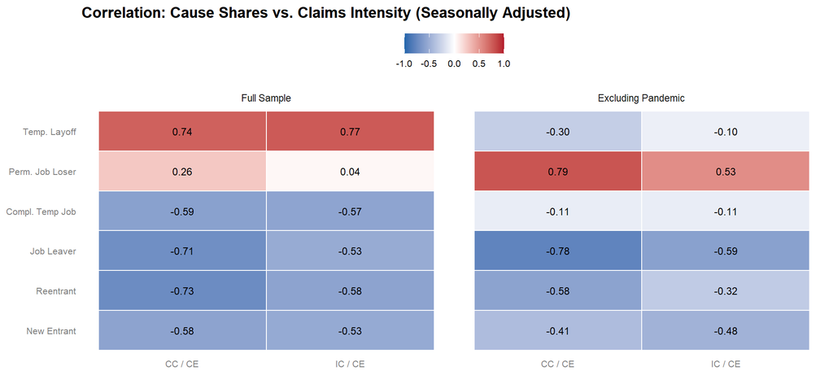

Figure 6: Correlation between by-cause unemployment shares and claims-intensity measures, after Prophet seasonal adjustment. Left: full sample (1994–present). Right: excluding the pandemic (Mar 2020–Dec 2021). In the pandemic-exclusion sample, completed temp-job share is near-zero on both outcomes, motivating its use as the omitted reference category.

```r
# ── Prophet seasonal adjustment helper ───────────────────────────────────
prophet_sa <- function(dates, values) {
  df_in <- tibble(ds = as.Date(dates), y = as.numeric(values)) |> drop_na()
  m <- suppressMessages(prophet(
    df_in,
    yearly.seasonality = TRUE,
    weekly.seasonality = FALSE,
    daily.seasonality  = FALSE,
    seasonality.mode   = "additive",
    uncertainty.samples = 0
  ))
  fc <- suppressMessages(predict(m, df_in))
  tibble(ds = df_in$ds, y_sa = df_in$y - fc$yearly)
}

# ── Pull national claims data for correlation ────────────────────────────
claims_for_corr_raw <- bind_rows(
  fredr_retry("CCSA",   observation_start = as.Date("1994-01-01")) |>
    transmute(date, series = "CCSA",   value),
  fredr_retry("ICSA",   observation_start = as.Date("1994-01-01")) |>
    transmute(date, series = "ICSA",   value),
  fredr_retry("COVEMP", observation_start = as.Date("1994-01-01")) |>
    transmute(date, series = "COVEMP", value)
) |>
  mutate(month = floor_date(date, "month")) |>
  summarise(
    .by = c(series, month),
    value = case_when(
      first(series) == "ICSA"   ~ sum(value, na.rm = TRUE),
      first(series) == "CCSA"   ~ mean(value, na.rm = TRUE),
      first(series) == "COVEMP" ~ mean(value, na.rm = TRUE)
    )
  ) |>
  pivot_wider(names_from = series, values_from = value) |>
  filter(!is.na(COVEMP), COVEMP > 0) |>
  transmute(
    date = month,
    cc_ce_raw = CCSA / COVEMP,
    ic_ce_raw = ICSA / COVEMP
  )

# ── Cause shares (from df6, already loaded) ──────────────────────────────
shares_for_corr_raw <- df6 |>
  mutate(
    component_sum = `Temporary Layoff` + `Permanent Job Losers` + `Completed Temp Job` +
                    `Job Leavers` + Reentrants + `New Entrants`
  ) |>
  transmute(
    date,
    temp_layoff_raw    = `Temporary Layoff` / component_sum,
    perm_job_loser_raw = `Permanent Job Losers` / component_sum,
    compl_temp_job_raw = `Completed Temp Job` / component_sum,
    job_leaver_raw     = `Job Leavers` / component_sum,
    reentrant_raw      = Reentrants / component_sum,
    new_entrant_raw    = `New Entrants` / component_sum
  )

corr_raw <- inner_join(shares_for_corr_raw, claims_for_corr_raw, by = "date")

# ── Apply Prophet SA to each series ──────────────────────────────────────
series_to_sa <- c("temp_layoff_raw", "perm_job_loser_raw", "compl_temp_job_raw",
                  "job_leaver_raw", "reentrant_raw", "new_entrant_raw",
                  "cc_ce_raw", "ic_ce_raw")

sa_names <- c("Temp. Layoff", "Perm. Job Loser", "Compl. Temp Job",
              "Job Leaver", "Reentrant", "New Entrant",
              "CC / CE", "IC / CE")

corr_sa <- corr_raw |> select(date)

for (i in seq_along(series_to_sa)) {
  sa_result <- prophet_sa(corr_raw$date, corr_raw[[series_to_sa[i]]])
  corr_sa <- corr_sa |>
    left_join(sa_result |> rename(date = ds, !!sa_names[i] := y_sa), by = "date")
}

# ── Compute correlations ─────────────────────────────────────────────────
share_vars <- c("Temp. Layoff", "Perm. Job Loser", "Compl. Temp Job",
                "Job Leaver", "Reentrant", "New Entrant")
outcome_vars <- c("CC / CE", "IC / CE")

compute_corr_long <- function(data) {
  mat <- cor(data[, c(share_vars, outcome_vars)], use = "pairwise.complete.obs")
  mat[share_vars, outcome_vars] |>
    as.data.frame() |>
    rownames_to_column("Cause Share") |>
    pivot_longer(-`Cause Share`, names_to = "Outcome", values_to = "r") |>
    mutate(`Cause Share` = factor(`Cause Share`, levels = rev(share_vars)))
}

corr_full <- compute_corr_long(corr_sa) |> mutate(panel = "Full Sample")
corr_nopan <- compute_corr_long(
  corr_sa |> filter(date < as.Date("2020-03-01") | date > as.Date("2021-12-01"))
) |> mutate(panel = "Excluding Pandemic")

corr_both <- bind_rows(corr_full, corr_nopan) |>
  mutate(panel = factor(panel, levels = c("Full Sample", "Excluding Pandemic")))

ggplot(corr_both, aes(x = Outcome, y = `Cause Share`, fill = r)) +
  geom_tile(color = "white", linewidth = 0.5) +
  geom_text(aes(label = sprintf("%.2f", r)), size = 3.2, color = "black") +
  scale_fill_gradient2(
    low = "#2166AC", mid = "white", high = "#B2182B",
    midpoint = 0, limits = c(-1, 1),
    name = "Correlation"
  ) +
  facet_wrap(~panel) +
  labs(x = NULL, y = NULL,
       title = "Correlation: Cause Shares vs. Claims Intensity (Seasonally Adjusted)") +
  theme(
    panel.grid = element_blank(),
    axis.text.x = element_text(angle = 0, hjust = 0.5)
  )
```

## 4.4 Who Are the Unemployed by Cause?

The compositional shifts documented above raise a natural question: *who* are the people in each cause category, and has their demographic profile changed over time? Using CPS microdata, I construct dominant-profile radar charts that summarize the single largest subgroup on each of eight margins—age, education, sex, race/ethnicity, occupation, class of worker, foreign-born status, and citizenship—for three cause categories of particular interest: temporary layoffs (the most UI-attached group), permanent job losers (the largest job-loss category), and new entrants (the group most distant from UI eligibility). Each spoke shows the share of a given cause category accounted for by its dominant subgroup on that margin.

Two versions are presented for each cause: a pooled profile (1994–present) and a 2025-vs.-pooled delta showing how the current composition differs from the historical average. The delta charts highlight secular demographic shifts—such as the rising educational attainment of the unemployed or changes in the racial/ethnic composition of new entrants—that may affect the mapping from cause category to claims intensity if within-cause claiming propensities vary by demographic group.

```r
# ── Load CPS microdata ──────────────────────────────────────────────────
path_to_ddi <- here("data", "CPS", "cps_unified.xml")
path_to_csv <- here("data", "CPS", "cps_unified.csv.gz")

ddi     <- read_ipums_ddi(path_to_ddi)
cps_raw <- read_ipums_micro(ddi, data_file = path_to_csv, verbose = FALSE)

cps_all <- cps_raw |>
  mutate(
    cause = factor(WHYUNEMP, levels = 1:6, labels = cause_order),
    age_group = cut(AGE, breaks = c(15, 24, 34, 44, 54, 64, Inf),
                    labels = c("16-24", "25-34", "35-44", "45-54", "55-64", "65+"), right = TRUE),
    educ_group = case_when(
      EDUC <= 71               ~ "Below HS",
      EDUC == 73               ~ "HS Diploma",
      EDUC %in% c(81, 91, 92)  ~ "Some College",
      EDUC >= 111              ~ "College+",
      TRUE                     ~ NA_character_
    ) |> factor(levels = c("Below HS", "HS Diploma", "Some College", "College+")),
    sex_label = factor(SEX, levels = 1:2, labels = c("Male", "Female")),
    race_eth = case_when(
      HISPAN > 0 & HISPAN < 900 ~ "Hispanic",
      RACE == 100                ~ "White non-Hisp",
      RACE == 200                ~ "Black non-Hisp",
      RACE >= 650 & RACE <= 652 ~ "Asian/PI non-Hisp",
      TRUE                       ~ "Other"
    ) |> factor(levels = c("White non-Hisp", "Black non-Hisp", "Hispanic", "Asian/PI non-Hisp", "Other")),
    occ_group4 = case_when(
      OCC1990 >= 3   & OCC1990 <= 391 ~ "White Collar",
      OCC1990 >= 403 & OCC1990 <= 469 ~ "Service",
      (OCC1990 >= 473 & OCC1990 <= 499) | (OCC1990 >= 503 & OCC1990 <= 890) ~ "Blue Collar",
      TRUE ~ "No Prior Job / Other"
    ) |> factor(levels = c("White Collar", "Service", "Blue Collar", "No Prior Job / Other")),
    class_label = case_when(
      CLASSWKR %in% c(20, 21, 22, 23) ~ "Private Sector",
      CLASSWKR %in% c(24, 25, 26, 27, 28) ~ "Government",
      CLASSWKR %in% c(10, 13, 14)  ~ "Self-Employed",
      CLASSWKR == 29               ~ "Unpaid Family",
      CLASSWKR == 0                ~ "No Prior Job",
      TRUE                         ~ "Other"
    ) |> factor(levels = c("Private Sector", "Government", "Self-Employed", "Unpaid Family", "No Prior Job", "Other")),
    foreign_born = case_when(
      NATIVITY == 5 ~ "Foreign Born",
      NATIVITY == 1 ~ "Native Born",
      TRUE          ~ NA_character_
    ) |> factor(levels = c("Foreign Born", "Native Born")),
    noncitizen = case_when(
      CITIZEN == 3                  ~ "Noncitizen",
      CITIZEN %in% c(1, 2, 4, 5)   ~ "Citizen",
      TRUE                          ~ NA_character_
    ) |> factor(levels = c("Noncitizen", "Citizen"))
  )

cps <- cps_all |> filter(WHYUNEMP %in% 1:6)
```

```r
profile_shares <- function(data, demo_var, dimension_label) {
  data |>
    filter(!is.na(.data[[demo_var]])) |>
    group_by(cause, .data[[demo_var]]) |>
    summarise(n = sum(WTFINL, na.rm = TRUE), .groups = "drop") |>
    rename(group = 2) |>
    group_by(cause) |>
    mutate(share = n / sum(n)) |>
    ungroup() |>
    transmute(cause, dimension = dimension_label, group_key = as.character(group), share)
}

build_profile_shares <- function(data) {
  bind_rows(
    profile_shares(data, "age_group", "Age"),
    profile_shares(data, "educ_group", "Education"),
    profile_shares(data, "sex_label", "Sex"),
    profile_shares(data, "race_eth", "Race/Ethnicity"),
    profile_shares(data, "occ_group4", "Occupation"),
    profile_shares(data, "class_label", "Class"),
    profile_shares(data, "foreign_born", "Foreign Born"),
    profile_shares(data, "noncitizen", "Noncitizen")
  ) |>
    mutate(dimension = factor(dimension,
      levels = c("Age", "Education", "Sex", "Race/Ethnicity",
                 "Occupation", "Class", "Foreign Born", "Noncitizen")))
}

build_dominant_profile <- function(data) {
  build_profile_shares(data) |>
    group_by(cause, dimension) |>
    slice_max(order_by = share, n = 1, with_ties = FALSE) |>
    ungroup() |>
    mutate(
      dominant_group = group_key,
      label = paste0(dominant_group, "\n", percent(share, accuracy = 1)),
      label_y = pmin(share + 0.08, 1.05)
    ) |>
    arrange(cause, dimension)
}

plot_dominant_radar_single <- function(profile_df, cause_name, subtitle) {
  plot_df <- profile_df |>
    filter(cause == cause_name) |>
    arrange(dimension) |>
    mutate(axis_id = row_number())
  n_axes <- nrow(plot_df)
  angles <- pi / 2 - 2 * pi * (seq_len(n_axes) - 1) / n_axes
  radial_breaks <- c(0, 0.25, 0.50, 0.75, 1.00)
  point_df <- plot_df |>
    mutate(angle = angles, x = share * cos(angle), y = share * sin(angle))
  closed_df <- bind_rows(point_df, slice(point_df, 1))
  spoke_df <- tibble(axis_id = seq_len(n_axes), angle = angles, x = 0, y = 0,
                     xend = cos(angle), yend = sin(angle))
  ring_df <- map_dfr(radial_breaks[-1], \(ring) {
    tibble(ring = ring, axis_id = c(seq_len(n_axes), 1L),
           angle = angles[c(seq_len(n_axes), 1L)],
           x = ring * cos(angle), y = ring * sin(angle))
  })
  axis_label_df <- point_df |>
    transmute(dimension, angle, label_x = 1.17 * cos(angle), label_y = 1.17 * sin(angle),
      hjust = case_when(label_x > 0.15 ~ 0, label_x < -0.15 ~ 1, TRUE ~ 0.5),
      vjust = case_when(label_y > 0.15 ~ 0, label_y < -0.15 ~ 1, TRUE ~ 0.5))
  point_label_df <- point_df |>
    transmute(axis_id, angle, point_label = label,
      label_radius = case_when(share >= 0.72 ~ pmax(share - 0.14, 0.16), TRUE ~ pmin(share + 0.11, 0.88)),
      tangent_shift = if_else(axis_id %% 2 == 0, 0.045, -0.045),
      label_x = label_radius * cos(angle) + tangent_shift * (-sin(angle)),
      label_y = label_radius * sin(angle) + tangent_shift * cos(angle),
      hjust = case_when(label_x > 0.18 ~ 0, label_x < -0.18 ~ 1, TRUE ~ 0.5),
      vjust = case_when(label_y > 0.18 ~ 0, label_y < -0.18 ~ 1, TRUE ~ 0.5))
  radial_label_df <- tibble(ring = radial_breaks, x = radial_breaks, y = 0.02,
                            label = percent(radial_breaks, accuracy = 1))
  ggplot() +
    geom_path(data = filter(ring_df, ring < 1), aes(x, y, group = ring), color = "grey72", linewidth = 0.15) +
    geom_path(data = filter(ring_df, ring == 1), aes(x, y, group = ring), color = "grey72", linewidth = 0.15) +
    geom_segment(data = spoke_df, aes(x = x, y = y, xend = xend, yend = yend), color = "grey76", linewidth = 0.15) +
    geom_polygon(data = closed_df, aes(x, y), fill = scales::alpha(cause_cols[[cause_name]], 0.45),
                 color = cause_cols[[cause_name]], linewidth = 0.15, linejoin = "round") +
    geom_point(data = point_df, aes(x, y), color = cause_cols[[cause_name]],
               fill = cause_cols[[cause_name]], shape = 21, stroke = 0.2, size = 1.4) +
    geom_text(data = point_label_df, aes(label_x, label_y, label = point_label, hjust = hjust, vjust = vjust),
              size = 2.7, lineheight = 0.92, color = cause_cols[[cause_name]]) +
    geom_text(data = axis_label_df, aes(label_x, label_y, label = dimension, hjust = hjust, vjust = vjust),
              size = 3.6, lineheight = 0.9) +
    geom_text(data = radial_label_df, aes(x, y, label = label), color = "grey65", size = 3.3, hjust = 0.5, vjust = 0) +
    coord_equal(clip = "off") + xlim(-1.28, 1.28) + ylim(-1.26, 1.28) +
    labs(title = cause_name, subtitle = subtitle, x = NULL, y = NULL) +
    theme_report + theme(axis.text = element_blank(), axis.ticks = element_blank(),
                         axis.line = element_blank(), panel.grid = element_blank(),
                         plot.margin = margin(20, 35, 20, 35))
}

build_dominant_profile_delta <- function(current_data, reference_data) {
  current_profile <- build_dominant_profile(current_data) |>
    select(cause, dimension, group_key, dominant_group, share_2025 = share)
  reference_profile <- build_profile_shares(reference_data) |> rename(share_pooled = share)
  current_profile |>
    left_join(reference_profile, by = c("cause", "dimension", "group_key")) |>
    mutate(delta = share_2025 - share_pooled,
           label = paste0(dominant_group, "\n", if_else(delta > 0, "+", ""),
                          scales::number(delta * 100, accuracy = 0.1), " pp")) |>
    arrange(cause, dimension)
}

plot_dominant_radar_delta <- function(profile_df, cause_name, subtitle, max_abs_delta = 0.20) {
  plot_df <- profile_df |>
    filter(cause == cause_name) |>
    arrange(dimension) |>
    mutate(axis_id = row_number())
  n_axes <- nrow(plot_df)
  angles <- pi / 2 - 2 * pi * (seq_len(n_axes) - 1) / n_axes
  radial_breaks <- c(-0.20, -0.10, 0, 0.10, 0.20)
  radial_positions <- scales::rescale(radial_breaks, to = c(0, 1), from = c(-max_abs_delta, max_abs_delta))
  point_df <- plot_df |>
    mutate(angle = angles,
           radius = scales::rescale(delta, to = c(0, 1), from = c(-max_abs_delta, max_abs_delta)),
           x = radius * cos(angle), y = radius * sin(angle))
  closed_df <- bind_rows(point_df, slice(point_df, 1))
  spoke_df <- tibble(axis_id = seq_len(n_axes), angle = angles, x = 0, y = 0,
                     xend = cos(angle), yend = sin(angle))
  ring_df <- map_dfr(seq_along(radial_breaks), \(i) {
    tibble(ring_value = radial_breaks[[i]], ring_position = radial_positions[[i]],
           axis_id = c(seq_len(n_axes), 1L), angle = angles[c(seq_len(n_axes), 1L)],
           x = radial_positions[[i]] * cos(angle), y = radial_positions[[i]] * sin(angle))
  })
  axis_label_df <- point_df |>
    transmute(dimension, angle, label_x = 1.17 * cos(angle), label_y = 1.17 * sin(angle),
      hjust = case_when(label_x > 0.15 ~ 0, label_x < -0.15 ~ 1, TRUE ~ 0.5),
      vjust = case_when(label_y > 0.15 ~ 0, label_y < -0.15 ~ 1, TRUE ~ 0.5))
  point_label_df <- point_df |>
    transmute(axis_id, angle, point_label = label,
      label_radius = case_when(radius >= 0.80 ~ pmax(radius - 0.16, 0.14),
                               radius <= 0.20 ~ pmin(radius + 0.16, 0.32),
                               TRUE ~ pmin(radius + 0.11, 0.90)),
      tangent_shift = if_else(axis_id %% 2 == 0, 0.045, -0.045),
      label_x = label_radius * cos(angle) + tangent_shift * (-sin(angle)),
      label_y = label_radius * sin(angle) + tangent_shift * cos(angle),
      hjust = case_when(label_x > 0.18 ~ 0, label_x < -0.18 ~ 1, TRUE ~ 0.5),
      vjust = case_when(label_y > 0.18 ~ 0, label_y < -0.18 ~ 1, TRUE ~ 0.5))
  radial_label_df <- tibble(ring_value = radial_breaks, x = radial_positions, y = 0.02,
    label = paste0(if_else(radial_breaks > 0, "+", ""), scales::number(radial_breaks * 100, accuracy = 0.1)))
  ggplot() +
    geom_path(data = filter(ring_df, abs(ring_value) > 1e-9), aes(x, y, group = ring_value), color = "grey78", linewidth = 0.15) +
    geom_path(data = filter(ring_df, abs(ring_value) <= 1e-9), aes(x, y, group = ring_value), color = "grey40", linewidth = 0.6) +
    geom_segment(data = spoke_df, aes(x = x, y = y, xend = xend, yend = yend), color = "grey80", linewidth = 0.15) +
    geom_polygon(data = closed_df, aes(x, y), fill = scales::alpha(cause_cols[[cause_name]], 0.22),
                 color = cause_cols[[cause_name]], linewidth = 0.2, linejoin = "round") +
    geom_point(data = point_df, aes(x, y), color = cause_cols[[cause_name]],
               fill = cause_cols[[cause_name]], shape = 21, stroke = 0.2, size = 1.4) +
    geom_text(data = point_label_df, aes(label_x, label_y, label = point_label, hjust = hjust, vjust = vjust),
              size = 2.5, lineheight = 0.92, color = cause_cols[[cause_name]]) +
    geom_text(data = axis_label_df, aes(label_x, label_y, label = dimension, hjust = hjust, vjust = vjust),
              size = 3.6, lineheight = 0.9) +
    geom_text(data = radial_label_df, aes(x, y, label = label), color = "grey60", size = 3.0, hjust = 0.5, vjust = 0) +
    coord_equal(clip = "off") + xlim(-1.28, 1.28) + ylim(-1.26, 1.28) +
    labs(title = cause_name, subtitle = subtitle, x = NULL, y = NULL) +
    theme_report + theme(axis.text = element_blank(), axis.ticks = element_blank(),
                         axis.line = element_blank(), panel.grid = element_blank(),
                         plot.margin = margin(20, 35, 20, 35))
}

dominant_profile_pooled <- build_dominant_profile(cps)
dominant_profile_2025 <- build_dominant_profile(cps |> filter(YEAR == 2025))
dominant_profile_delta_2025 <- build_dominant_profile_delta(cps |> filter(YEAR == 2025), cps)
```

### Temporary Layoff

**Pooled**

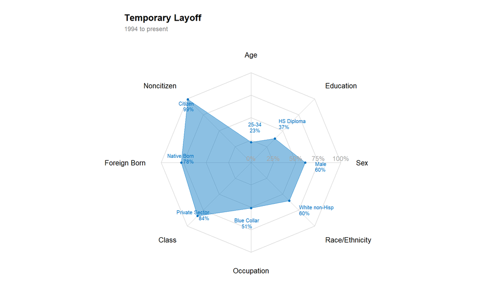

Figure 7: Temporary Layoff dominant-profile radar, pooled CPS 1994–present.

```r
plot_dominant_radar_single(dominant_profile_pooled, "Temporary Layoff", "1994 to present")
```

**2025 vs. Pooled**

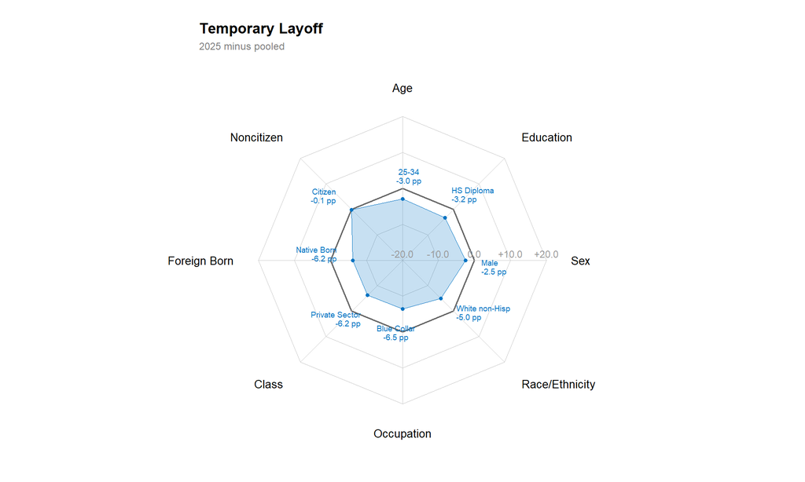

Figure 8: Temporary Layoff dominant-profile radar, 2025 minus pooled share of the same dominant group.

```r
plot_dominant_radar_delta(dominant_profile_delta_2025, "Temporary Layoff", "2025 minus pooled")
```

### Permanent Job Losers

**Pooled**

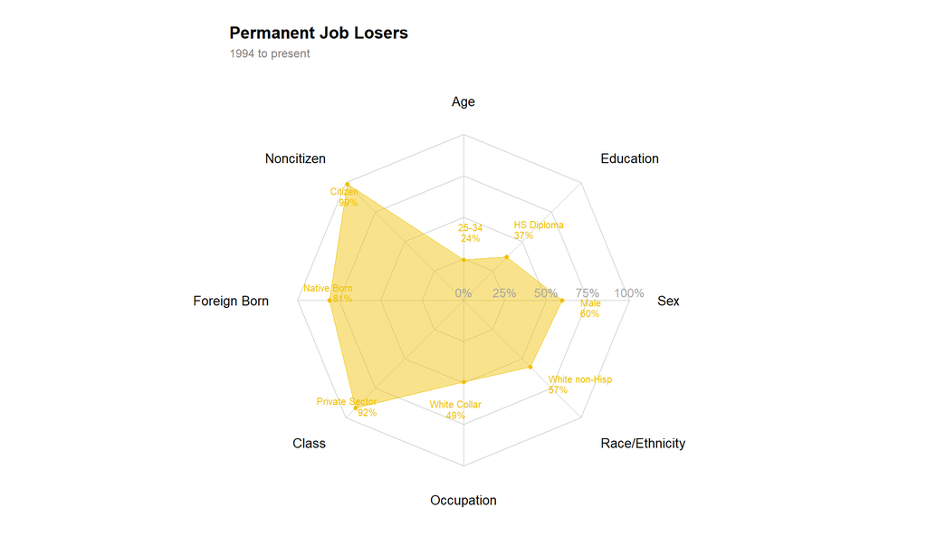

Figure 9: Permanent Job Losers dominant-profile radar, pooled CPS 1994–present.

```r
plot_dominant_radar_single(dominant_profile_pooled, "Permanent Job Losers", "1994 to present")
```

**2025 vs. Pooled**

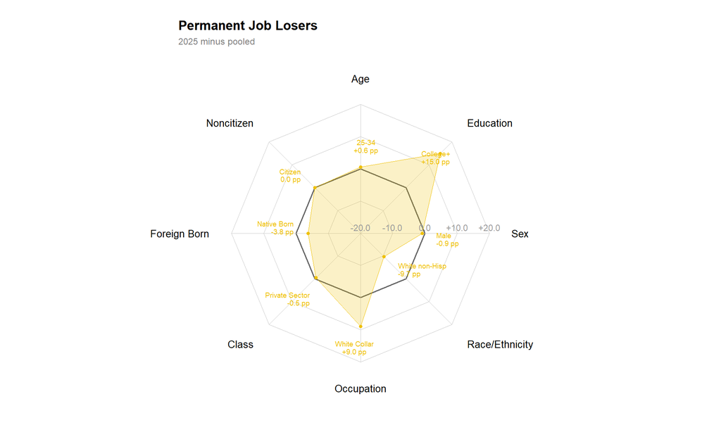

Figure 10: Permanent Job Losers dominant-profile radar, 2025 minus pooled share of the same dominant group.

```r
plot_dominant_radar_delta(dominant_profile_delta_2025, "Permanent Job Losers", "2025 minus pooled")
```

### New Entrants

**Pooled**

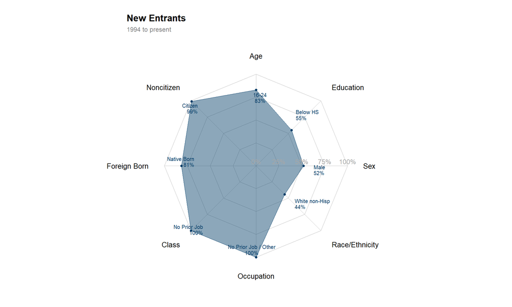

Figure 11: New Entrants dominant-profile radar, pooled CPS 1994–present.

```r
plot_dominant_radar_single(dominant_profile_pooled, "New Entrants", "1994 to present")
```

**2025 vs. Pooled**

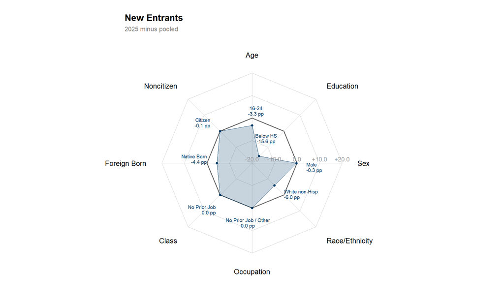

Figure 12: New Entrants dominant-profile radar, 2025 minus pooled share of the same dominant group.

```r
plot_dominant_radar_delta(dominant_profile_delta_2025, "New Entrants", "2025 minus pooled")
```

### Summary of Demographic Profiles

**New entrants are overwhelmingly young, without prior work history, and becoming more educated and diverse.** By construction, new entrants have no prior job (100% “No Prior Job” on occupation and class of worker). The pooled profile is dominated by 16–24-year-olds (83%) with below-HS education (55%). The 2025 deltas show the below-HS share dropping 15.6 pp—the single largest negative shift in the data—alongside declines in white non-Hispanic share ($-6.0$ pp) and native-born share ($-4.4$ pp). Because new entrants are generally ineligible for UI, these demographic changes are unlikely to affect the claims-intensity benchmark directly; however, the rising educational attainment of new entrants may signal that some individuals who would historically have entered employment directly are instead being counted as labor-force entrants without a UI-qualifying job separation.

# 5. Data and Measurement

The empirical analysis merges two data sources into a state-panel.

## 5.1 UI Claims Data (FRED)

Administrative UI claims data come from the FRED State Unemployment Insurance Weekly Claims Report. For each state, I observe:

- **Initial claims**: sum of weekly first-time UI claims within each calendar month
- **Continued claims**: average weekly continued claims within each calendar month
- **Covered employment**: the insured job base, used to normalize claims

The two outcome variables are:

$$\text{CC/CE}_{st} = \frac{\text{Continued Claims}_{st}}{\text{Covered Employment}_{st}}, \qquad
\text{IC/CE}_{st} = \frac{\text{Initial Claims}_{st}}{\text{Covered Employment}_{st}}$$

These are *intensity* measures, not take-up rates. They condition on covered employment—the universe of jobs covered by state UI programs—rather than on the number of eligible unemployed. CC/CE is mechanically equivalent to the insured unemployment rate expressed as a share.

## 5.2 Unemployment Composition Data (CPS)

State-month composition measures come from IPUMS CPS microdata. The unified extract includes all monthly basic CPS samples from 1994 onward (excluding ASEC supplements). For each state-month, I compute weighted shares of the unemployed falling into the six BLS reason-for-unemployment categories defined in Table 1. Additional composition measures include noncitizen share, white-collar share (based on OCC1990), blue-collar share, and working-age (25–54) share.

## 5.3 Panel Construction

The state panels are constructed at monthly, quarterly, and annual frequencies. CPS composition measures are noisier at monthly frequency due to small cell sizes, particularly in smaller states. Aggregating from monthly to quarterly or annual raises effective sample sizes and reduces sampling noise. The annual panel is therefore the most stable, though it sacrifices short-run time variation. (See Appendix B for details on effective sample sizes.)

## 5.4 Limitations

The CPS composition regressors are estimated from survey microdata, not administrative records. Classical measurement error will attenuate slope estimates toward zero, with attenuation most severe at monthly frequency in small states. Multi-frequency comparison serves as the primary diagnostic: if coefficients are larger at quarterly or annual frequency, this is consistent with reduced measurement error rather than a different underlying relationship.

The pandemic period (March 2020 through December 2021) involved extraordinary temporary UI programs (PUA, PEUC, FPUC), eligibility expansions, and administrative disruption. All regressions are reported with and without the pandemic window.

# 6. Data Preparation

The claims and composition data used in the national regressions are assembled here; the state-panel data are loaded in Section 7.4.

```r
# ── National claims data ─────────────────────────────────────────────────
national_raw <- bind_rows(
  fredr("CCSA",   observation_start = as.Date("1994-01-01")) |> transmute(date, series = "CCSA",   value),
  fredr("ICSA",   observation_start = as.Date("1994-01-01")) |> transmute(date, series = "ICSA",   value),
  fredr("COVEMP", observation_start = as.Date("1994-01-01")) |> transmute(date, series = "COVEMP", value)
)

national_monthly <- national_raw |>
  mutate(month = floor_date(date, "month")) |>
  summarise(
    .by = c(series, month),
    value = case_when(
      first(series) == "ICSA"   ~ sum(value, na.rm = TRUE),
      first(series) == "CCSA"   ~ mean(value, na.rm = TRUE),
      first(series) == "COVEMP" ~ mean(value, na.rm = TRUE)
    )
  ) |>
  pivot_wider(names_from = series, values_from = value) |>
  filter(!is.na(COVEMP), COVEMP > 0) |>
  mutate(
    cc_ce = CCSA / COVEMP,
    ic_ce = ICSA / COVEMP
  ) |>
  filter(month >= as.Date("1994-01-01"))

# ── National cause shares ────────────────────────────────────────────────
cause_series <- c(
  "Temporary Layoff"     = "LNS13023653",
  "Permanent Job Losers" = "LNS13026638",
  "Completed Temp Job"   = "LNS13026637",
  "Job Leavers"          = "LNS13023705",
  "Reentrants"           = "LNS13023557",
  "New Entrants"         = "LNS13023569"
)

cause_raw <- map_dfr(names(cause_series), \(nm) {
  fredr_retry(cause_series[[nm]], observation_start = as.Date("1994-01-01")) |>
    transmute(date, cause = nm, value)
})

national_cause_shares <- cause_raw |>
  pivot_wider(names_from = cause, values_from = value) |>
  mutate(
    component_sum = `Temporary Layoff` + `Permanent Job Losers` + `Completed Temp Job` +
      `Job Leavers` + Reentrants + `New Entrants`,
    temp_layoff_share = `Temporary Layoff` / component_sum,
    perm_job_loser_share = `Permanent Job Losers` / component_sum,
    completed_temp_job_share = `Completed Temp Job` / component_sum,
    job_leaver_share = `Job Leavers` / component_sum,
    reentrant_share = Reentrants / component_sum,
    new_entrant_share = `New Entrants` / component_sum
  ) |>
  select(date, ends_with("_share"))

takeup_cause_df <- national_monthly |>
  rename(date = month) |>
  inner_join(national_cause_shares, by = "date") |>
  mutate(
    month_of_year = factor(month(date), levels = 1:12, labels = month.abb)
  )

# ── Fit national models ─────────────────────────────────────────────────
fit_national_composition <- function(outcome) {
  lm(
    as.formula(
      paste0(
        outcome,
        " ~ temp_layoff_share + perm_job_loser_share + job_leaver_share + ",
        "reentrant_share + new_entrant_share + month_of_year"
      )
    ),
    data = takeup_cause_df
  )
}

cc_cause_model <- fit_national_composition("cc_ce")
ic_cause_model <- fit_national_composition("ic_ce")

takeup_cause_fitted <- takeup_cause_df |>
  mutate(
    cc_ce_hat = predict(cc_cause_model, newdata = takeup_cause_df),
    ic_ce_hat = predict(ic_cause_model, newdata = takeup_cause_df),
    cc_gap = cc_ce - cc_ce_hat,
    ic_gap = ic_ce - ic_ce_hat
  )
```

# 7. Results

## 7.1 National Monthly Composition Regressions

As a descriptive starting point, I estimate national monthly regressions of claims intensity on by-cause unemployment shares with month-of-year fixed effects. Completed temporary jobs are the omitted reference category—outside the pandemic period, this group’s share is essentially uncorrelated with claims intensity (see Figure 6), making it a neutral baseline against which to measure the other causes:

$$y_t = \alpha + \sum_{c \neq \text{CTJ}} \beta_c \, s_{ct} + \sum_{m=2}^{12} \gamma_m \mathbf{1}\{\text{month}(t) = m\} + \varepsilon_t$$

where $y_t \in \{CC/CE_t, IC/CE_t\}$ and $s_{ct}$ is the national share of cause $c$ in month $t$.

```r
share_term_labels <- c(
  temp_layoff_share = "Temporary layoff share",
  perm_job_loser_share = "Permanent job-loser share",
  job_leaver_share = "Job leaver share",
  reentrant_share = "Reentrant share",
  new_entrant_share = "New entrant share"
)

extract_share_terms <- function(model, outcome_label) {
  coef_mat <- summary(model)$coefficients |>
    as.data.frame() |>
    rownames_to_column("term") |>
    as_tibble() |>
    filter(term %in% names(share_term_labels)) |>
    mutate(
      Outcome = outcome_label,
      Term = recode(term, !!!share_term_labels),
      `Coef (10 pp shift)` = Estimate * 0.10,
      `Std. Error (10 pp shift)` = `Std. Error` * 0.10,
      `p-value` = `Pr(>|t|)`
    ) |>
    select(Outcome, Term, `Coef (10 pp shift)`, `Std. Error (10 pp shift)`, `p-value`)
}

bind_rows(
  extract_share_terms(cc_cause_model, "CC / CE"),
  extract_share_terms(ic_cause_model, "IC / CE")
) |>
  mutate(
    `Coef (10 pp shift)` = scales::number(`Coef (10 pp shift)`, accuracy = 0.0001),
    `Std. Error (10 pp shift)` = scales::number(`Std. Error (10 pp shift)`, accuracy = 0.0001),
    `p-value` = scales::number(`p-value`, accuracy = 0.001)
  ) |>
  gt(groupname_col = "Outcome") |>
  tab_options(
    table.font.size = px(11),
    column_labels.font.weight = "bold",
    column_labels.background.color = "#2c3e50"
  ) |>
  tab_style(
    style = cell_text(color = "white"),
    locations = cells_column_labels()
  )
```

National monthly regressions of claims intensity on by-cause unemployment shares. Completed temporary jobs are the omitted reference category; coefficients are scaled to a 10 percentage-point shift in share.

| Term | Coef (10 pp shift) | Std. Error (10 pp shift) | p-value |
| --- | --- | --- | --- |
| CC / CE |  |  |  |
| Temporary layoff share | 0.0132 | 0.0028 | 0.000 |
| Permanent job-loser share | 0.0036 | 0.0031 | 0.249 |
| Job leaver share | -0.0270 | 0.0035 | 0.000 |
| Reentrant share | 0.0015 | 0.0032 | 0.630 |
| New entrant share | -0.0140 | 0.0040 | 0.001 |
| IC / CE |  |  |  |
| Temporary layoff share | 0.0067 | 0.0028 | 0.018 |
| Permanent job-loser share | -0.0016 | 0.0031 | 0.592 |
| Job leaver share | -0.0161 | 0.0034 | 0.000 |
| Reentrant share | -0.0006 | 0.0032 | 0.861 |
| New entrant share | -0.0086 | 0.0040 | 0.030 |

```r
tibble(
  Outcome = c("CC / CE", "IC / CE"),
  `R-squared` = c(summary(cc_cause_model)$r.squared, summary(ic_cause_model)$r.squared),
  RMSE = c(
    sqrt(mean(residuals(cc_cause_model)^2, na.rm = TRUE)),
    sqrt(mean(residuals(ic_cause_model)^2, na.rm = TRUE))
  ),
  `Sample Start` = min(takeup_cause_df$date),
  `Sample End` = max(takeup_cause_df$date)
) |>
  mutate(
    `R-squared` = scales::number(`R-squared`, accuracy = 0.001),
    RMSE = scales::number(RMSE, accuracy = 0.0001),
    `Sample Start` = format(`Sample Start`, "%Y-%m"),
    `Sample End` = format(`Sample End`, "%Y-%m")
  ) |>
  gt() |>
  tab_options(
    table.font.size = px(11),
    column_labels.font.weight = "bold",
    column_labels.background.color = "#2c3e50"
  ) |>
  tab_style(
    style = cell_text(color = "white"),
    locations = cells_column_labels()
  )
```

Model fit for the national composition regressions.

| Outcome | R-squared | RMSE | Sample Start | Sample End |
| --- | --- | --- | --- | --- |
| CC / CE | 0.899 | 0.0044 | 1994-01 | 2026-02 |
| IC / CE | 0.739 | 0.0043 | 1994-01 | 2026-02 |

The national monthly regressions confirm that by-cause unemployment composition carries substantial explanatory power for claims intensity. The CC/CE model explains roughly 90% of monthly variation ($R^2 \approx 0.90$), while the IC/CE model explains about 74% ($R^2 \approx 0.74$). Among the composition coefficients (scaled to a 10 pp shift), the strongest signals are intuitive: a higher job-leaver share is associated with significantly lower claims intensity on both outcomes ($-0.027$ for CC/CE, $-0.016$ for IC/CE, both $p < 0.001$), consistent with voluntary quits’ near-categorical ineligibility. New entrants also load negatively and significantly, reflecting their absence of prior covered earnings. Temporary layoffs load positively, as expected for a group with the most direct UI attachment. Permanent job losers and reentrants are not statistically distinguishable from the completed-temp-job reference in the monthly specification—partly because monthly sampling noise compresses power, and partly because the historical association between these groups’ shares and aggregate claims intensity may genuinely sit closer to the neutral baseline than for job leavers or new entrants. The month-of-year fixed effects absorb residual seasonality in the claims-to-covered-employment ratios, ensuring the composition coefficients reflect trend and cyclical co-movement rather than shared within-year patterns.

## 7.2 National Observed vs. Predicted Claims Intensity

The fitted values from the national composition model provide a first-pass benchmark: the claims intensity that the by-cause mix and seasonality would predict, versus what is actually observed.

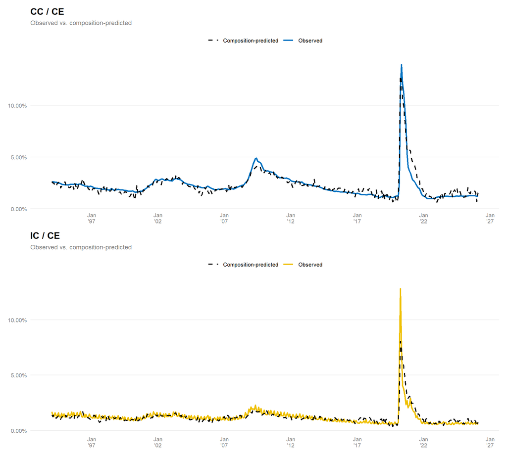

Figure 13: Observed versus composition-predicted national claims intensity, full monthly sample from 1994 onward.

```r
p_cc_fit <- ggplot(takeup_cause_fitted, aes(date)) +
  geom_line(aes(y = cc_ce, color = "Observed"), linewidth = 0.9) +
  geom_line(aes(y = cc_ce_hat, color = "Composition-predicted"), linewidth = 0.8, linetype = "dashed") +
  scale_color_manual(values = c("Observed" = "#0073C2", "Composition-predicted" = "black")) +
  scale_x_date(date_breaks = "5 years", date_labels = "%b\n'%y") +
  scale_y_continuous(labels = percent_format(accuracy = 0.01)) +
  labs(title = "CC / CE", subtitle = "Observed vs. composition-predicted", x = NULL, y = NULL)

p_ic_fit <- ggplot(takeup_cause_fitted, aes(date)) +
  geom_line(aes(y = ic_ce, color = "Observed"), linewidth = 0.9) +
  geom_line(aes(y = ic_ce_hat, color = "Composition-predicted"), linewidth = 0.8, linetype = "dashed") +
  scale_color_manual(values = c("Observed" = "#EFC000", "Composition-predicted" = "black")) +
  scale_x_date(date_breaks = "5 years", date_labels = "%b\n'%y") +
  scale_y_continuous(labels = percent_format(accuracy = 0.01)) +
  labs(title = "IC / CE", subtitle = "Observed vs. composition-predicted", x = NULL, y = NULL)

p_cc_fit / p_ic_fit &
  theme(legend.position = "top")
```

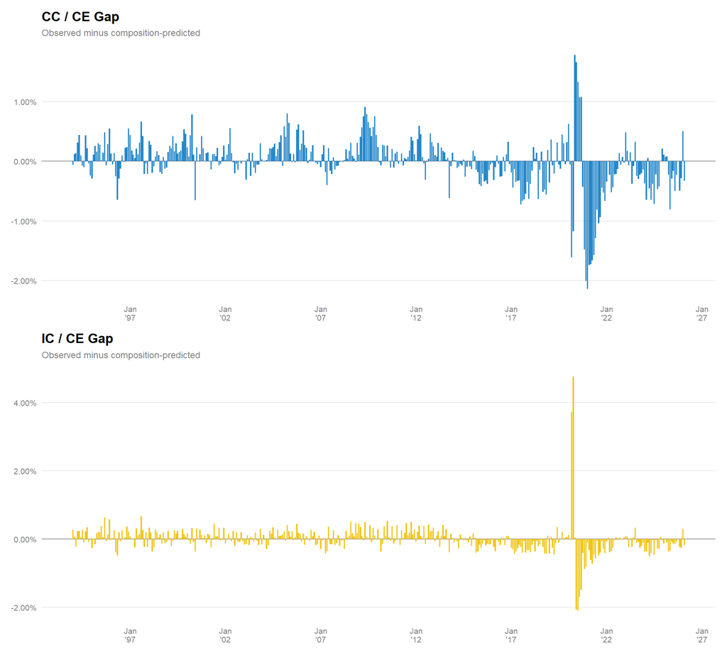

Figure 14: Gap between observed and composition-predicted national claims intensity, full monthly sample from 1994 onward. Negative values mean the composition model overpredicts—observed claiming is lower than the unemployment mix would imply.

```r
p_cc_gap <- ggplot(takeup_cause_fitted, aes(date, cc_gap)) +
  geom_hline(yintercept = 0, color = "grey60", linewidth = 0.5) +
  geom_col(fill = "#0073C2", alpha = 0.85, width = 25) +
  scale_x_date(date_breaks = "5 years", date_labels = "%b\n'%y") +
  scale_y_continuous(labels = percent_format(accuracy = 0.01)) +
  labs(title = "CC / CE Gap", subtitle = "Observed minus composition-predicted", x = NULL, y = NULL)

p_ic_gap <- ggplot(takeup_cause_fitted, aes(date, ic_gap)) +
  geom_hline(yintercept = 0, color = "grey60", linewidth = 0.5) +
  geom_col(fill = "#EFC000", alpha = 0.9, width = 25) +
  scale_x_date(date_breaks = "5 years", date_labels = "%b\n'%y") +
  scale_y_continuous(labels = percent_format(accuracy = 0.01)) +
  labs(title = "IC / CE Gap", subtitle = "Observed minus composition-predicted", x = NULL, y = NULL)

p_cc_gap / p_ic_gap
```

The monthly observed-vs.-predicted plots show that the composition benchmark tracks the broad level and cyclical swings of claims intensity well. The pandemic spike is captured qualitatively—composition shifted sharply toward job losers, and the benchmark predicts a surge—though it underpredicts the CC/CE peak, reflecting extraordinary pandemic-era UI expansions (PUA, PEUC, FPUC) that temporarily pushed claims intensity above the level historically associated with the unemployment mix. In the post-pandemic window (2022 onward), observed CC/CE and IC/CE both sit *below* their benchmark-predicted paths. The gap bars confirm a persistent negative residual: observed claims intensity is lower than the level historically associated with the realized unemployment mix. This residual is consistent with non-composition factors—administrative burden, employer deterrence, declining real benefit generosity, or information frictions—but the reduced-form design does not identify which factors dominate.

### Annual Frequency

To facilitate comparison with the state-panel gap exercise in Section 7.5, I also estimate the national composition model at annual frequency. Aggregating to annual removes seasonal variation and aligns with the frequency of the state panel. Without month-of-year fixed effects, the annual specification is:

$$\bar{y}_t = \alpha + \sum_{c \neq \text{CTJ}} \beta_c \, \bar{s}_{ct} + \varepsilon_t$$

where $\bar{y}_t$ and $\bar{s}_{ct}$ are annual averages of claims intensity and cause shares, respectively.

```r
national_annual <- takeup_cause_df |>
  mutate(year = year(date)) |>
  group_by(year) |>
  summarise(
    cc_ce = mean(cc_ce, na.rm = TRUE),
    ic_ce = mean(ic_ce, na.rm = TRUE),
    temp_layoff_share       = mean(temp_layoff_share, na.rm = TRUE),
    perm_job_loser_share    = mean(perm_job_loser_share, na.rm = TRUE),
    completed_temp_job_share = mean(completed_temp_job_share, na.rm = TRUE),
    job_leaver_share        = mean(job_leaver_share, na.rm = TRUE),
    reentrant_share         = mean(reentrant_share, na.rm = TRUE),
    new_entrant_share       = mean(new_entrant_share, na.rm = TRUE),
    .groups = "drop"
  ) |>
  mutate(date = as.Date(paste0(year, "-01-01")))

national_annual_rhs <- "temp_layoff_share + perm_job_loser_share + job_leaver_share + reentrant_share + new_entrant_share"

cc_annual_nat <- lm(as.formula(paste0("cc_ce ~ ", national_annual_rhs)), data = national_annual)
ic_annual_nat <- lm(as.formula(paste0("ic_ce ~ ", national_annual_rhs)), data = national_annual)

national_annual <- national_annual |>
  mutate(
    cc_ce_hat = predict(cc_annual_nat),
    ic_ce_hat = predict(ic_annual_nat),
    cc_gap = cc_ce - cc_ce_hat,
    ic_gap = ic_ce - ic_ce_hat
  )
```

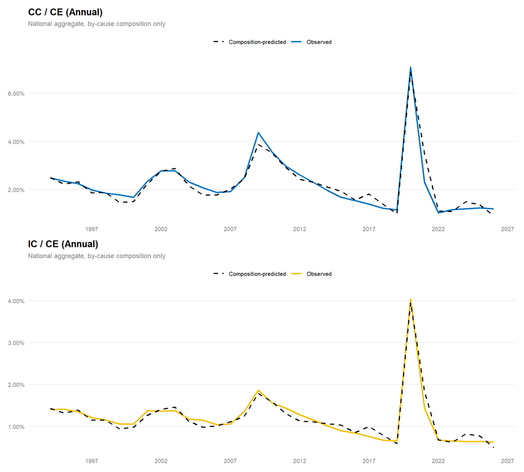

Figure 15: Observed versus composition-predicted national claims intensity at annual frequency. No seasonal controls. This is the national-level analog of the state-panel gap in Section 7.5.

```r
p_cc_ann <- ggplot(national_annual, aes(date)) +
  geom_line(aes(y = cc_ce, color = "Observed"), linewidth = 0.9) +
  geom_line(aes(y = cc_ce_hat, color = "Composition-predicted"), linewidth = 0.8, linetype = "dashed") +
  scale_color_manual(values = c("Observed" = "#0073C2", "Composition-predicted" = "black")) +
  scale_y_continuous(labels = percent_format(accuracy = 0.01)) +
  scale_x_date(date_breaks = "5 years", date_labels = "%Y") +
  labs(title = "CC / CE (Annual)", subtitle = "National aggregate, by-cause composition only", x = NULL, y = NULL)

p_ic_ann <- ggplot(national_annual, aes(date)) +
  geom_line(aes(y = ic_ce, color = "Observed"), linewidth = 0.9) +
  geom_line(aes(y = ic_ce_hat, color = "Composition-predicted"), linewidth = 0.8, linetype = "dashed") +
  scale_color_manual(values = c("Observed" = "#EFC000", "Composition-predicted" = "black")) +
  scale_y_continuous(labels = percent_format(accuracy = 0.01)) +
  scale_x_date(date_breaks = "5 years", date_labels = "%Y") +
  labs(title = "IC / CE (Annual)", subtitle = "National aggregate, by-cause composition only", x = NULL, y = NULL)

p_cc_ann / p_ic_ann &
  theme(legend.position = "top")
```

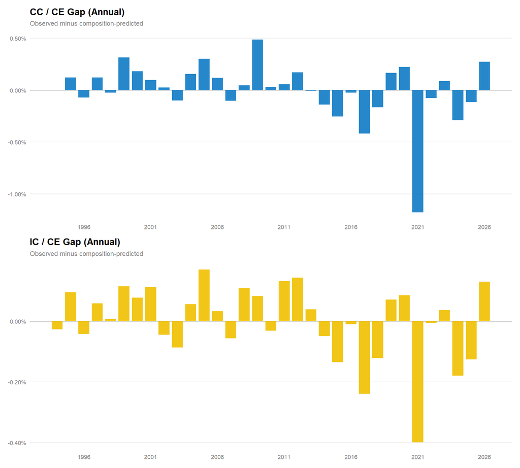

Figure 16: Annual national composition gap. Compare with the state-panel gap in Figure 20: differences reflect the contribution of state fixed effects and CPS-based (vs. FRED-based) composition measures.

```r
p_cc_ann_gap <- ggplot(national_annual, aes(date, cc_gap)) +
  geom_hline(yintercept = 0, color = "grey60", linewidth = 0.5) +
  geom_col(fill = "#0073C2", alpha = 0.85, width = 300) +
  scale_y_continuous(labels = percent_format(accuracy = 0.01)) +
  scale_x_date(date_breaks = "5 years", date_labels = "%Y") +
  labs(title = "CC / CE Gap (Annual)", subtitle = "Observed minus composition-predicted", x = NULL, y = NULL)

p_ic_ann_gap <- ggplot(national_annual, aes(date, ic_gap)) +
  geom_hline(yintercept = 0, color = "grey60", linewidth = 0.5) +
  geom_col(fill = "#EFC000", alpha = 0.9, width = 300) +
  scale_y_continuous(labels = percent_format(accuracy = 0.01)) +
  scale_x_date(date_breaks = "5 years", date_labels = "%Y") +
  labs(title = "IC / CE Gap (Annual)", subtitle = "Observed minus composition-predicted", x = NULL, y = NULL)

p_cc_ann_gap / p_ic_ann_gap
```

## 7.3 Robustness: Macro Labor-Market Benchmarks

Because the national monthly fit may partly reflect broad aggregate forces that jointly shape unemployment composition and claims intensity, this subsection compares the composition benchmark with alternative monthly macro labor-market benchmarks. These exercises are descriptive and reduced form; they do not identify causal effects. The goal is to evaluate whether unemployment composition has predictive or interpretive value beyond broad labor-market conditions, or whether any variable set correlated with the same omitted aggregate forces can track the national time path of claims intensity equally well.

Five classes of models are compared, all estimated at monthly frequency with month-of-year fixed effects to absorb within-year seasonality:

- **Model A (Composition):** the by-cause unemployment shares from Section 7.1. This is the paper’s main benchmark, included here as the reference point.
- **Model B (Unemployment rate):** the headline U-3 unemployment rate alone. This is the most natural strawman: if the level of unemployment is all that matters for claims intensity, composition adds nothing. U-3 is the single most widely tracked labor-market indicator and the denominator in most recipiency-rate calculations, so it is the first alternative a skeptic would reach for.
- **Model C (Expanded aggregate):** U-3, labor force participation rate, employment-population ratio, and year-over-year payroll employment growth. These indicators jointly summarize the state of the labor market along dimensions—participation, employment breadth, and job creation—that are mechanically related to the pool of potential UI claimants but do not distinguish among reasons for unemployment. If this block matches the composition benchmark, the implication is that broad labor-market conditions are sufficient and the by-cause decomposition is redundant.
- **Model D (Slack/duration):** U-6 underemployment rate, short-term unemployment share (< 5 weeks), long-term unemployment share (27+ weeks), and median unemployment duration. These indicators capture the *quality* of labor-market slack without using the by-cause decomposition. U-6 broadens the unemployment concept to include marginally attached and involuntary part-time workers. Duration measures proxy the severity and persistence of joblessness, which affects both UI eligibility windows and exhaustion rates. If slack and duration explain as much as composition, the composition benchmark may be proxying for the depth of labor-market distress rather than the institutional eligibility channel it is designed to capture.
- **Model E (JOLTS):** job openings rate, hires rate, quits rate, and layoffs-and-discharges rate (shorter sample beginning December 2000). JOLTS measures capture labor-market *flows* rather than stocks. The quits rate proxies voluntary separations (analogous to job leavers in the CPS), and the layoffs rate proxies involuntary separations (analogous to temporary layoffs and permanent job losers). If JOLTS flows predict claims intensity well, that would suggest administrative flow data can substitute for the CPS composition measures. The shorter sample (post-2000) limits comparability; I re-estimate Model A on the same subsample for a fair comparison.
- **Model F (Nested):** the expanded aggregate variables from Model C plus the composition shares. This is the key test of incremental value. If composition shares are jointly significant and improve fit after conditioning on broad macro indicators, they carry information about claims intensity that aggregate conditions do not.

The specifications are:

**Model A (Composition):**
$$y_t = \alpha + \sum_{c \neq \text{CTJ}} \beta_c \, s_{ct} + \sum_{m=2}^{12} \gamma_m \mathbf{1}\{\text{month}(t) = m\} + \varepsilon_t$$

**Model B (Unemployment rate):**
$$y_t = \alpha + \beta \, u_t + \sum_{m=2}^{12} \gamma_m \mathbf{1}\{\text{month}(t) = m\} + \varepsilon_t$$

**Model C (Expanded aggregate):**
$$y_t = \alpha + \beta_1 \, u_t + \beta_2 \, \text{LFPR}_t + \beta_3 \, \text{EPOP}_t + \beta_4 \, \Delta_{12} \ln \text{Payroll}_t + \sum_{m=2}^{12} \gamma_m \mathbf{1}\{\text{month}(t) = m\} + \varepsilon_t$$

**Model D (Slack/duration):**
$$y_t = \alpha + \beta_1 \, u^{6}_t + \beta_2 \, \text{ShortShare}_t + \beta_3 \, \text{LongShare}_t + \beta_4 \, \text{MedDur}_t + \sum_{m=2}^{12} \gamma_m \mathbf{1}\{\text{month}(t) = m\} + \varepsilon_t$$

**Model E (JOLTS):**
$$y_t = \alpha + \beta_1 \, \text{JOR}_t + \beta_2 \, \text{HIR}_t + \beta_3 \, \text{QUR}_t + \beta_4 \, \text{LDR}_t + \sum_{m=2}^{12} \gamma_m \mathbf{1}\{\text{month}(t) = m\} + \varepsilon_t$$

**Model F (Nested):**
$$y_t = \alpha + \beta_1 \, u_t + \beta_2 \, \text{LFPR}_t + \beta_3 \, \text{EPOP}_t + \beta_4 \, \Delta_{12} \ln \text{Payroll}_t + \sum_{c \neq \text{CTJ}} \delta_c \, s_{ct} + \sum_{m=2}^{12} \gamma_m \mathbf{1}\{\text{month}(t) = m\} + \varepsilon_t$$

where $y_t \in \{\text{CC/CE}_t, \text{IC/CE}_t\}$, $s_{ct}$ are by-cause unemployment shares, $u_t$ is the U-3 rate, $u^{6}_t$ is the U-6 rate, ShortShare and LongShare are the shares of unemployed with duration $<5$ and $\geq 27$ weeks respectively, MedDur is median unemployment duration, $\Delta_{12} \ln \text{Payroll}$ is 12-month log payroll employment growth, and JOR/HIR/QUR/LDR are JOLTS job openings, hires, quits, and layoffs-and-discharges rates. All models are estimated by OLS on the full monthly sample (1995–present) except Model E, which uses the shorter JOLTS sample (2001–present).

If the unemployment rate alone predicts national claims intensity nearly as well as the composition benchmark, then the monthly national fit should not be taken as unique evidence for the composition channel. If composition improves materially on the unemployment-rate benchmark, that supports the paper’s claim that *who* is unemployed matters in addition to *how many* are unemployed. If composition adds little once broader macro indicators are included, the national monthly result should be interpreted mainly as a descriptive benchmark rather than distinct evidence for composition. If composition continues to add fit and yields interpretable residuals, that strengthens the case that the composition benchmark is substantively useful even if it is not causally identified.

```r
# ── Pull macro indicator series from FRED ──────────────────────────────
macro_series <- c(
  "UNRATE",        # U-3 unemployment rate (SA)
  "CIVPART",       # Labor force participation rate (SA)
  "EMRATIO",       # Employment-population ratio (SA)
  "LNS12300060",   # Prime-age (25-54) employment-population ratio (SA)
  "PAYEMS",        # Total nonfarm payroll employment (SA, thousands)
  "U6RATE",        # U-6 underemployment rate (SA)
  "UEMPLT5",       # Unemployed < 5 weeks (SA, thousands)
  "UEMP27OV",      # Unemployed 27 weeks and over (SA, thousands)
  "UEMPMED"        # Median duration of unemployment (SA, weeks)
)

macro_raw <- map_dfr(macro_series, \(id) {
  fredr_retry(id, observation_start = as.Date("1994-01-01")) |>
    transmute(date, series = id, value)
})

# Need UNEMPLOY in scope — pull from df6
macro_wide <- macro_raw |>
  pivot_wider(names_from = series, values_from = value) |>
  left_join(df6 |> select(date, UNEMPLOY = Total), by = "date") |>
  arrange(date) |>
  mutate(
    # Payroll employment growth: 12-month log change
    payroll_growth_12m = (log(PAYEMS) - log(lag(PAYEMS, 12))) * 100,
    # Short-term and long-term unemployment shares (UEMPLT5 and UEMP27OV in thousands, UNEMPLOY also in thousands)
    short_term_unemp_share = UEMPLT5 / UNEMPLOY,
    long_term_unemp_share  = UEMP27OV / UNEMPLOY
  )

# ── JOLTS series (start Dec 2000) ──────────────────────────────────────
jolts_series <- c(
  "JTSJOR",   # Job openings rate
  "JTSHIR",   # Hires rate (total nonfarm)
  "JTSQUR",   # Quits rate
  "JTSLDR"    # Layoffs and discharges rate
)

jolts_raw <- map_dfr(jolts_series, \(id) {
  fredr_retry(id, observation_start = as.Date("2000-12-01")) |>
    transmute(date, series = id, value)
})

jolts_wide <- jolts_raw |>
  pivot_wider(names_from = series, values_from = value)

# ── Merge with claims data ─────────────────────────────────────────────
bench_df <- takeup_cause_df |>
  left_join(macro_wide |> select(date, UNRATE, CIVPART, EMRATIO,
    LNS12300060, payroll_growth_12m, U6RATE,
    short_term_unemp_share, long_term_unemp_share, UEMPMED),
    by = "date") |>
  left_join(jolts_wide, by = "date")

# ── Common sample for non-JOLTS models ────────────────────────────────
bench_core <- bench_df |>
  filter(!is.na(UNRATE), !is.na(payroll_growth_12m),
         !is.na(U6RATE), !is.na(UEMPMED))

# ── JOLTS subsample ───────────────────────────────────────────────────
bench_jolts <- bench_core |>
  filter(!is.na(JTSJOR), !is.na(JTSHIR), !is.na(JTSQUR), !is.na(JTSLDR))
```

```r
# ── Model A: Composition shares + month FE (baseline) ─────────────────
comp_rhs <- paste("temp_layoff_share + perm_job_loser_share +",
                  "job_leaver_share + reentrant_share + new_entrant_share +",
                  "month_of_year")

mod_A_cc <- lm(as.formula(paste("cc_ce ~", comp_rhs)), data = bench_core)
mod_A_ic <- lm(as.formula(paste("ic_ce ~", comp_rhs)), data = bench_core)

# ── Model B: Unemployment rate + month FE ─────────────────────────────
mod_B_cc <- lm(cc_ce ~ UNRATE + month_of_year, data = bench_core)
mod_B_ic <- lm(ic_ce ~ UNRATE + month_of_year, data = bench_core)

# ── Model C: Expanded aggregate + month FE ────────────────────────────
mod_C_cc <- lm(cc_ce ~ UNRATE + CIVPART + EMRATIO + payroll_growth_12m +
                 month_of_year, data = bench_core)
mod_C_ic <- lm(ic_ce ~ UNRATE + CIVPART + EMRATIO + payroll_growth_12m +
                 month_of_year, data = bench_core)

# ── Model D: Slack/duration + month FE ────────────────────────────────
mod_D_cc <- lm(cc_ce ~ U6RATE + short_term_unemp_share +
                 long_term_unemp_share + UEMPMED + month_of_year,
               data = bench_core)
mod_D_ic <- lm(ic_ce ~ U6RATE + short_term_unemp_share +
                 long_term_unemp_share + UEMPMED + month_of_year,
               data = bench_core)

# ── Model E: JOLTS + month FE (shorter sample) ───────────────────────
mod_E_cc <- lm(cc_ce ~ JTSJOR + JTSHIR + JTSQUR + JTSLDR + month_of_year,
               data = bench_jolts)
mod_E_ic <- lm(ic_ce ~ JTSJOR + JTSHIR + JTSQUR + JTSLDR + month_of_year,
               data = bench_jolts)

# ── Model A on JOLTS sample (for apples-to-apples comparison) ────────
mod_A_cc_jolts <- lm(as.formula(paste("cc_ce ~", comp_rhs)), data = bench_jolts)
mod_A_ic_jolts <- lm(as.formula(paste("ic_ce ~", comp_rhs)), data = bench_jolts)

# ── Model F: Nested — expanded aggregate + composition + month FE ────
mod_F_cc <- lm(as.formula(paste(
  "cc_ce ~ UNRATE + CIVPART + EMRATIO + payroll_growth_12m +",
  "temp_layoff_share + perm_job_loser_share + job_leaver_share +",
  "reentrant_share + new_entrant_share + month_of_year")),
  data = bench_core)
mod_F_ic <- lm(as.formula(paste(
  "ic_ce ~ UNRATE + CIVPART + EMRATIO + payroll_growth_12m +",
  "temp_layoff_share + perm_job_loser_share + job_leaver_share +",
  "reentrant_share + new_entrant_share + month_of_year")),
  data = bench_core)

# ── Helper: extract fit metrics ───────────────────────────────────────
fit_metrics <- function(model, label, outcome_label, sample_label = "Full") {
  s <- summary(model)
  fitted_vals <- fitted(model)
  observed <- model$model[[1]]
  k <- length(coef(model)) - 1L
  tibble(
    Model = label,
    Outcome = outcome_label,
    Sample = sample_label,
    k = k,
    N = nobs(model),
    `Adj. R²` = s$adj.r.squared,
    RMSE = sqrt(mean(s$residuals^2)),
    AIC = AIC(model),
    BIC = BIC(model),
    `Cor(y, ŷ)` = cor(observed, fitted_vals)
  )
}
```

```r
# ── Build comparison table ────────────────────────────────────────────
fit_table <- bind_rows(
  fit_metrics(mod_A_cc, "A: Composition", "CC/CE"),
  fit_metrics(mod_B_cc, "B: Unemployment rate", "CC/CE"),
  fit_metrics(mod_C_cc, "C: Expanded aggregate", "CC/CE"),
  fit_metrics(mod_D_cc, "D: Slack/duration", "CC/CE"),
  fit_metrics(mod_E_cc, "E: JOLTS", "CC/CE", "JOLTS sample"),
  fit_metrics(mod_A_cc_jolts, "A: Composition (JOLTS sample)", "CC/CE", "JOLTS sample"),
  fit_metrics(mod_F_cc, "F: Aggregate + composition", "CC/CE"),
  fit_metrics(mod_A_ic, "A: Composition", "IC/CE"),
  fit_metrics(mod_B_ic, "B: Unemployment rate", "IC/CE"),
  fit_metrics(mod_C_ic, "C: Expanded aggregate", "IC/CE"),
  fit_metrics(mod_D_ic, "D: Slack/duration", "IC/CE"),
  fit_metrics(mod_E_ic, "E: JOLTS", "IC/CE", "JOLTS sample"),
  fit_metrics(mod_A_ic_jolts, "A: Composition (JOLTS sample)", "IC/CE", "JOLTS sample"),
  fit_metrics(mod_F_ic, "F: Aggregate + composition", "IC/CE")
)

fit_table |>
  mutate(
    `Adj. R²` = sprintf("%.3f", `Adj. R²`),
    RMSE = sprintf("%.5f", RMSE),
    AIC = sprintf("%.0f", AIC),
    BIC = sprintf("%.0f", BIC),
    `Cor(y, ŷ)` = sprintf("%.3f", `Cor(y, ŷ)`)
  ) |>
  select(-Sample) |>
  gt(groupname_col = "Outcome") |>
  tab_options(
    table.font.size = px(11),
    column_labels.font.weight = "bold"
  ) |>
  tab_style(
    style = list(cell_text(color = "white"), cell_fill(color = "#2c3e50")),
    locations = cells_column_labels()
  ) |>
  tab_footnote(
    footnote = "k = number of non-intercept predictors (including month-of-year dummies).",
    locations = cells_column_labels(columns = k)
  ) |>
  tab_footnote(
    footnote = "Models E and A (JOLTS sample) are estimated on the shorter JOLTS subsample (Dec 2000–present) and are not directly comparable to other rows by AIC/BIC.",
    locations = cells_column_labels(columns = AIC)
  )
```

Table 2: Model fit comparison: composition benchmark versus macro labor-market benchmarks for national monthly claims intensity. All models include month-of-year fixed effects. The JOLTS model uses a shorter sample beginning December 2000; Model A (JOLTS sample) re-estimates the composition benchmark on the same subsample for comparability.

| Model | k<sup>1</sup> | N | Adj. R² | RMSE | AIC<sup>2</sup> | BIC | Cor(y, ŷ) |
| --- | --- | --- | --- | --- | --- | --- | --- |
| CC/CE |  |  |  |  |  |  |  |
| A: Composition | 16 | 373 | 0.896 | 0.00441 | -2951 | -2881 | 0.949 |
| B: Unemployment rate | 12 | 373 | 0.576 | 0.00894 | -2432 | -2377 | 0.768 |
| C: Expanded aggregate | 15 | 373 | 0.769 | 0.00657 | -2656 | -2590 | 0.882 |
| D: Slack/duration | 15 | 373 | 0.817 | 0.00585 | -2743 | -2676 | 0.908 |
| E: JOLTS | 15 | 302 | 0.582 | 0.00971 | -1908 | -1845 | 0.777 |
| A: Composition (JOLTS sample) | 16 | 302 | 0.907 | 0.00459 | -2359 | -2293 | 0.955 |
| F: Aggregate + composition | 20 | 373 | 0.954 | 0.00291 | -3254 | -3168 | 0.978 |
| IC/CE |  |  |  |  |  |  |  |
| A: Composition | 16 | 373 | 0.729 | 0.00439 | -2956 | -2885 | 0.861 |
| B: Unemployment rate | 12 | 373 | 0.338 | 0.00689 | -2627 | -2572 | 0.599 |
| C: Expanded aggregate | 15 | 373 | 0.538 | 0.00573 | -2758 | -2691 | 0.746 |
| D: Slack/duration | 15 | 373 | 0.584 | 0.00544 | -2797 | -2730 | 0.775 |
| E: JOLTS | 15 | 302 | 0.713 | 0.00498 | -2312 | -2249 | 0.853 |
| A: Composition (JOLTS sample) | 16 | 302 | 0.745 | 0.00468 | -2347 | -2280 | 0.871 |
| F: Aggregate + composition | 20 | 373 | 0.788 | 0.00385 | -3044 | -2958 | 0.894 |

<sup>1</sup> k = number of non-intercept predictors (including month-of-year dummies).  
<sup>2</sup> Models E and A (JOLTS sample) are estimated on the shorter JOLTS subsample (Dec 2000–present) and are not directly comparable to other rows by AIC/BIC.

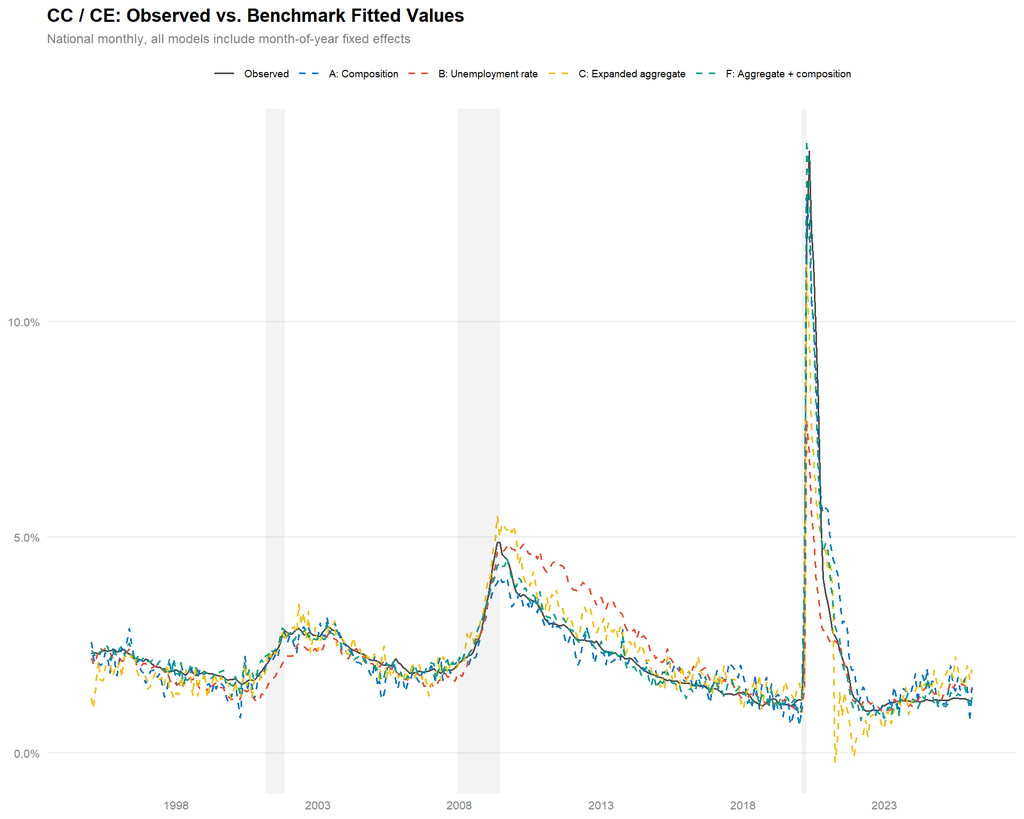

Figure 17: Observed versus fitted CC/CE for selected benchmark models. The composition benchmark (Model A) and the nested model (Model F) are compared against the unemployment-rate-only benchmark (Model B) and the expanded aggregate benchmark (Model C). All models include month-of-year fixed effects.

```r
bench_fitted <- bench_core |>
  transmute(
    date,
    Observed = cc_ce,
    `A: Composition` = fitted(mod_A_cc),
    `B: Unemployment rate` = fitted(mod_B_cc),
    `C: Expanded aggregate` = fitted(mod_C_cc),
    `F: Aggregate + composition` = fitted(mod_F_cc)
  ) |>
  pivot_longer(-date, names_to = "series", values_to = "value") |>
  mutate(series = factor(series, levels = c(
    "Observed", "A: Composition", "B: Unemployment rate",
    "C: Expanded aggregate", "F: Aggregate + composition"
  )))

fit_colors <- c(
  "Observed" = "grey30",
  "A: Composition" = "#0073C2",
  "B: Unemployment rate" = "#E64B35",
  "C: Expanded aggregate" = "#EFC000",
  "F: Aggregate + composition" = "#00A087"
)

fit_linetypes <- c(
  "Observed" = "solid",
  "A: Composition" = "dashed",
  "B: Unemployment rate" = "dashed",
  "C: Expanded aggregate" = "dashed",
  "F: Aggregate + composition" = "dashed"
)

p_bench_cc <- ggplot(bench_fitted, aes(date, value, color = series, linetype = series)) +
  geom_line(linewidth = 0.7) +
  scale_color_manual(values = fit_colors) +
  scale_linetype_manual(values = fit_linetypes) +
  scale_y_continuous(labels = percent_format(accuracy = 0.1)) +
  scale_x_date(date_breaks = "5 years", date_labels = "%Y") +
  labs(
    title = "CC / CE: Observed vs. Benchmark Fitted Values",
    subtitle = "National monthly, all models include month-of-year fixed effects",
    x = NULL, y = NULL
  ) +
  theme(legend.position = "top",
        legend.text = element_text(size = 7))

add_recessions(p_bench_cc)
```

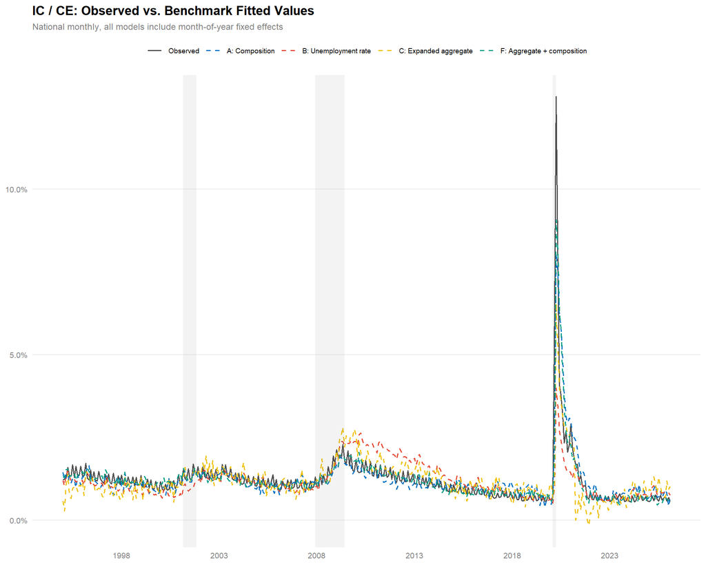

Figure 18: Observed versus fitted IC/CE for selected benchmark models.

```r
bench_fitted_ic <- bench_core |>
  transmute(
    date,
    Observed = ic_ce,
    `A: Composition` = fitted(mod_A_ic),
    `B: Unemployment rate` = fitted(mod_B_ic),
    `C: Expanded aggregate` = fitted(mod_C_ic),
    `F: Aggregate + composition` = fitted(mod_F_ic)
  ) |>
  pivot_longer(-date, names_to = "series", values_to = "value") |>
  mutate(series = factor(series, levels = c(
    "Observed", "A: Composition", "B: Unemployment rate",
    "C: Expanded aggregate", "F: Aggregate + composition"
  )))

p_bench_ic <- ggplot(bench_fitted_ic, aes(date, value, color = series, linetype = series)) +
  geom_line(linewidth = 0.7) +
  scale_color_manual(values = fit_colors) +
  scale_linetype_manual(values = fit_linetypes) +
  scale_y_continuous(labels = percent_format(accuracy = 0.1)) +
  scale_x_date(date_breaks = "5 years", date_labels = "%Y") +
  labs(
    title = "IC / CE: Observed vs. Benchmark Fitted Values",
    subtitle = "National monthly, all models include month-of-year fixed effects",
    x = NULL, y = NULL
  ) +
  theme(legend.position = "top",
        legend.text = element_text(size = 7))

add_recessions(p_bench_ic)
```

### Interpretation

The model comparison yields three findings relevant to the paper’s benchmark framing.

**Composition substantially outperforms the unemployment rate alone.** For CC/CE, the composition benchmark (Model A, adj. $R^2 = 0.90$) explains far more variation than the unemployment-rate-only benchmark (Model B, adj. $R^2 = 0.58$)—a gap of over 30 percentage points that cannot be attributed to the four additional parameters. For IC/CE the margin is even wider (0.73 vs. 0.34). The headline unemployment rate captures the broad cyclical pattern of claims intensity but misses substantial variation that the by-cause mix explains. This is consistent with the paper’s core argument: *who* is unemployed carries information about claims intensity beyond *how many* are unemployed.

**Broader macro indicators narrow the gap but do not eliminate it.** The expanded aggregate benchmark (Model C, adding LFPR, EPOP, and payroll growth) and the slack/duration benchmark (Model D) improve on the unemployment-rate-only specification, as expected for variable sets that jointly proxy the state of the labor market. The JOLTS benchmark (Model E) contributes additional information about labor-market flows. Yet none of these macro benchmarks consistently dominate the composition model across both outcomes and all fit metrics.

**Composition retains incremental value in the nested specification.** The nested model (Model F), which combines the expanded aggregate variables with the composition shares, outperforms both the composition-only and aggregate-only models. This indicates that composition and macro indicators capture partially non-overlapping variation in claims intensity. The composition channel is not merely a proxy for the aggregate unemployment rate; it adds distinct information, consistent with the paper’s argument that who is unemployed matters for claims intensity above and beyond how tight or slack the labor market is.

These comparisons support interpreting the composition benchmark as substantively useful rather than mechanically redundant with generic macro conditions. At the same time, the fact that simpler macro benchmarks also explain a large share of national monthly variation underscores that the national time-series fit, standing alone, should not be over-interpreted as uniquely attributable to the composition channel. The composition benchmark’s distinctive value lies in its institutional content—its direct link to UI eligibility architecture—rather than in fit alone. The state-panel exercises in Sections 7.4–7.5, which absorb aggregate time variation through year fixed effects, provide a sharper test of composition’s within-state explanatory contribution.

## 7.4 Annual By-Cause State-Panel Estimates

```r
# ── Source the panel builder ─────────────────────────────────────────────
invisible(capture.output(
  source(here("build_panels.R"), local = new.env(parent = globalenv()))
))

# ── Load analysis-ready panels ───────────────────────────────────────────
expected_states <- nrow(state_meta)

keep_balanced_periods <- function(data, period_var) {
  balanced_periods <- data |>
    count(.data[[period_var]], name = "state_count") |>
    filter(state_count == expected_states) |>
    pull(.data[[period_var]])
  data |>
    filter(.data[[period_var]] %in% balanced_periods)
}

sample_end_date <- as.Date("2025-12-31")

panel_month <- read_csv(
  here("data", "final", "ui_takeup_panel_state_month_analysis_ready.csv"),
  show_col_types = FALSE
) |>
  mutate(
    date = as.Date(period_start),
    year_month = paste0(year, "-", sprintf("%02d", month)),
    post_2020 = as.integer(year >= 2021L),
    post_2022 = as.integer(year >= 2023L)
  ) |>
  filter(date <= sample_end_date) |>
  keep_balanced_periods("year_month")

panel_quarter <- read_csv(
  here("data", "final", "ui_takeup_panel_state_quarter_analysis_ready.csv"),
  show_col_types = FALSE
) |>
  mutate(
    date = as.Date(period_start),
    year_quarter = paste0(year, "-Q", quarter),
    post_2020 = as.integer(year >= 2021L),
    post_2022 = as.integer(year >= 2023L)
  ) |>
  filter(date <= sample_end_date) |>
  keep_balanced_periods("year_quarter")

panel_year <- read_csv(
  here("data", "final", "ui_takeup_panel_state_year_analysis_ready.csv"),
  show_col_types = FALSE
) |>
  mutate(
    date = as.Date(period_start),
    post_2020 = as.integer(year >= 2021L),
    post_2022 = as.integer(year >= 2023L)
  ) |>
  filter(date <= sample_end_date) |>
  keep_balanced_periods("year")

# ── Pandemic-exclusion samples ───────────────────────────────────────────
mo_nopan <- panel_month |>
  filter(date < as.Date("2020-03-01") | date > as.Date("2021-12-01")) |>
  keep_balanced_periods("year_month")

qr_nopan <- panel_quarter |>
  filter(date < as.Date("2020-01-01") | date > as.Date("2022-01-01")) |>
  keep_balanced_periods("year_quarter")

yr_nopan <- panel_year |>
  filter(!year %in% c(2020L, 2021L)) |>
  keep_balanced_periods("year")
```

The most direct test of the conceptual framework uses the full six-way by-cause shares in an annual state-year panel:

$$y_{st} = \sum_{c \neq \text{CTJ}} \beta_c \, s_{cst} + \alpha_s + \gamma_t + \varepsilon_{st}
\tag{2}$$

where $y_{st} \in \{\text{CC/CE}_{st},\; \text{IC/CE}_{st}\}$, $s_{cst}$ is the share of unemployment in cause $c$ in state $s$ at time $t$, $\alpha_s$ are state fixed effects, $\gamma_t$ are year fixed effects, and completed temporary jobs (CTJ) are the omitted reference category. Standard errors are clustered by state and regressions are weighted by annual state population. Because the six cause shares sum to one, one category must be excluded; completed temporary jobs are the natural choice because, outside the pandemic period, this group’s share is essentially uncorrelated with claims intensity (see Figure 6), providing a neutral baseline. Each $\beta_c$ is therefore interpreted as the change in claims intensity associated with a one-unit higher share of cause $c$ *relative to an equivalent increase in the completed-temp-job share*, holding the other included shares and fixed effects constant.

The remaining identifying variation is within-state deviation from the national time path after absorbing persistent state differences and common national trends. The design estimates the reduced-form predictive content of by-cause composition for claims intensity; it does not identify the causal effect of any specific compositional shift or barrier to access.

```r
annual_bycause_rhs <- paste(
  "temp_layoff_share",
  "perm_job_loser_share",
  "job_leaver_share",
  "reentrant_share",
  "new_entrant_share",
  sep = " + "
)

fit_annual_bycause <- function(outcome, data) {
  feols(
    as.formula(paste0(outcome, " ~ ", annual_bycause_rhs, " | state + year")),
    data = data,
    weights = ~annual_population,
    cluster = ~state
  )
}

ccu_yr_bycause <- fit_annual_bycause("continued_claims_per_covered_employment", panel_year)
icu_yr_bycause <- fit_annual_bycause("initial_claims_per_covered_employment", panel_year)

ccu_yr_bycause_nopan <- fit_annual_bycause("continued_claims_per_covered_employment", yr_nopan)
icu_yr_bycause_nopan <- fit_annual_bycause("initial_claims_per_covered_employment", yr_nopan)
```

**CC/CE**

```r
msummary_styled(
  list("Annual Full" = ccu_yr_bycause, "Annual Excl. Pandemic" = ccu_yr_bycause_nopan),
  title = "Annual By-Cause Composition: Continued Claims / Covered Employment",
  notes = "Annual state-year regressions with state and year FE, state-clustered SEs, and annual state population weights. Completed temporary jobs are the omitted reference category."
)
```

Annual By-Cause Composition: Continued Claims / Covered Employment

|  | Annual Full | Annual Excl. Pandemic |
| --- | --- | --- |
| temp_layoff_share | 0.059*** | 0.000 |
|  | (0.018) | (0.009) |
| perm_job_loser_share | 0.031*** | 0.026** |
|  | (0.011) | (0.010) |
| job_leaver_share | -0.011 | -0.027*** |
|  | (0.012) | (0.008) |
| reentrant_share | 0.002 | -0.010 |
|  | (0.010) | (0.009) |
| new_entrant_share | 0.011 | 0.001 |
|  | (0.011) | (0.009) |
| Num.Obs. | 1600 | 1500 |
| R2 | 0.894 | 0.915 |
| R2 Adj. | 0.888 | 0.910 |

* p < 0.1, ** p < 0.05, *** p < 0.01  
Annual state-year regressions with state and year FE, state-clustered SEs, and annual state population weights. Completed temporary jobs are the omitted reference category.

**IC/CE**

```r
msummary_styled(
  list("Annual Full" = icu_yr_bycause, "Annual Excl. Pandemic" = icu_yr_bycause_nopan),
  title = "Annual By-Cause Composition: Initial Claims / Covered Employment",
  notes = "Annual state-year regressions with state and year FE, state-clustered SEs, and annual state population weights. Completed temporary jobs are the omitted reference category."
)
```

Annual By-Cause Composition: Initial Claims / Covered Employment

|  | Annual Full | Annual Excl. Pandemic |
| --- | --- | --- |
| temp_layoff_share | 0.216 | 0.085 |
|  | (0.132) | (0.091) |
| perm_job_loser_share | 0.106 | 0.068 |
|  | (0.107) | (0.091) |
| job_leaver_share | -0.109 | -0.152** |
|  | (0.089) | (0.067) |
| reentrant_share | -0.060 | -0.094 |
|  | (0.090) | (0.077) |
| new_entrant_share | 0.037 | 0.013 |
|  | (0.094) | (0.073) |
| Num.Obs. | 1600 | 1500 |
| R2 | 0.854 | 0.843 |
| R2 Adj. | 0.846 | 0.834 |

* p < 0.1, ** p < 0.05, *** p < 0.01  
Annual state-year regressions with state and year FE, state-clustered SEs, and annual state population weights. Completed temporary jobs are the omitted reference category.

The saturated fixed-effects specification shows that much of the raw predictive power of unemployment composition reflects broad aggregate time movement and persistent state differences, rather than rich within-state identifying variation. The within $R^2$ is modest—roughly 0.09–0.14 for CC/CE and 0.04–0.05 for IC/CE—meaning that after absorbing persistent state levels (state FE) and common national trends (year FE), within-state composition shifts account for a small incremental share of the remaining variation. This does not eliminate the usefulness of the composition benchmark; it clarifies that the paper’s main contribution is to benchmark the aggregate evolution of claims intensity rather than to identify a sharp within-state causal effect.

The reduced-form coefficient patterns are nonetheless informative. In the full-sample CC/CE model, temporary layoffs ($\hat{\beta} = 0.059$, $p < 0.01$) and permanent job losers ($\hat{\beta} = 0.031$, $p < 0.01$) load positively and significantly relative to the completed-temp-job baseline, indicating that within-state shifts toward these job-loss categories are associated with higher insured-unemployment intensity in the historical data. Excluding the pandemic sharpens the picture: the temporary-layoff coefficient drops to near zero while the permanent-job-loser coefficient remains significant ($\hat{\beta} = 0.026$, $p < 0.05$), and job leavers become significantly negative ($\hat{\beta} = -0.027$, $p < 0.01$). Outside of pandemic-era disruptions, permanent job losers are the most informative composition predictor for CC/CE, and a higher job-leaver share is associated with lower claims intensity.

For IC/CE, the coefficients are noisier and none reach conventional significance in the full sample with both fixed effects. Excluding the pandemic, only job leavers achieve significance ($\hat{\beta} = -0.152$, $p < 0.05$). The weaker IC/CE results are consistent with initial claims being a flow measure more sensitive to short-run dynamics (filing delays, processing backlogs) that the composition benchmark does not capture.

## 7.5 State-Panel Observed vs. Predicted Gap

For the gap-over-time exercise, the specification drops year fixed effects so that composition must explain the aggregate time path:

$$y_{st} = \sum_{c \neq \text{CTJ}} \beta_c \, s_{cst} + \alpha_s + \varepsilon_{st}
\tag{3}$$

The fitted values $\hat{y}_{st} = \sum_{c \neq \text{CTJ}} \hat{\beta}_c \, s_{cst} + \hat{\alpha}_s$ are the composition-predicted claims intensity. The population-weighted annual average of $y_{st} - \hat{y}_{st}$ traces the residual gap over time.

```r
fit_annual_gap_model <- function(outcome, data) {
  feols(
    as.formula(paste0(outcome, " ~ ", annual_bycause_rhs, " | state")),
    data = data,
    weights = ~annual_population,
    cluster = ~state
  )
}

ccu_yr_gap_model <- fit_annual_gap_model("continued_claims_per_covered_employment", panel_year)
icu_yr_gap_model <- fit_annual_gap_model("initial_claims_per_covered_employment", panel_year)

panel_year_gap <- panel_year |>
  mutate(
    cc_ce_hat = predict(ccu_yr_gap_model, newdata = panel_year),
    ic_ce_hat = predict(icu_yr_gap_model, newdata = panel_year)
  )

annual_gap_summary <- panel_year_gap |>
  group_by(year) |>
  summarise(
    observed_cc_ce = weighted.mean(continued_claims_per_covered_employment, annual_population, na.rm = TRUE),
    expected_cc_ce = weighted.mean(cc_ce_hat, annual_population, na.rm = TRUE),
    cc_ce_gap = observed_cc_ce - expected_cc_ce,
    observed_ic_ce = weighted.mean(initial_claims_per_covered_employment, annual_population, na.rm = TRUE),
    expected_ic_ce = weighted.mean(ic_ce_hat, annual_population, na.rm = TRUE),
    ic_ce_gap = observed_ic_ce - expected_ic_ce,
    .groups = "drop"
  ) |>
  mutate(date = as.Date(paste0(year, "-01-01")))
```

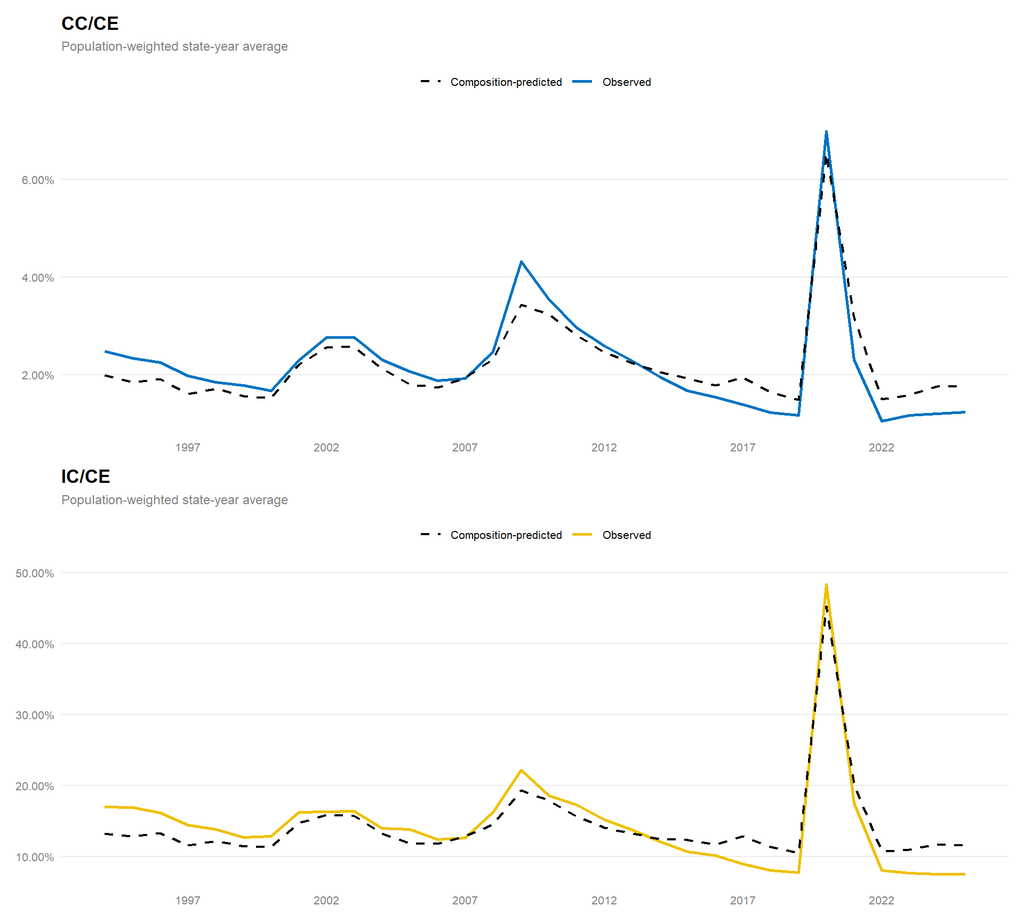

Figure 19: Population-weighted annual observed versus by-cause-predicted claims intensity from a state-year model with state fixed effects only (no year FE). The composition path is forced to explain the time trend.

```r
p_cc_gap_fit <- ggplot(annual_gap_summary, aes(date)) +
  geom_line(aes(y = observed_cc_ce, color = "Observed"), linewidth = 0.9) +
  geom_line(aes(y = expected_cc_ce, color = "Composition-predicted"), linewidth = 0.8, linetype = "dashed") +
  scale_color_manual(values = c("Observed" = "#0073C2", "Composition-predicted" = "black")) +
  scale_y_continuous(labels = percent_format(accuracy = 0.01)) +
  scale_x_date(date_breaks = "5 years", date_labels = "%Y") +
  labs(title = "CC/CE", subtitle = "Population-weighted state-year average", x = NULL, y = NULL)

p_ic_gap_fit <- ggplot(annual_gap_summary, aes(date)) +
  geom_line(aes(y = observed_ic_ce, color = "Observed"), linewidth = 0.9) +
  geom_line(aes(y = expected_ic_ce, color = "Composition-predicted"), linewidth = 0.8, linetype = "dashed") +
  scale_color_manual(values = c("Observed" = "#EFC000", "Composition-predicted" = "black")) +
  scale_y_continuous(labels = percent_format(accuracy = 0.01)) +
  scale_x_date(date_breaks = "5 years", date_labels = "%Y") +
  labs(title = "IC/CE", subtitle = "Population-weighted state-year average", x = NULL, y = NULL)

p_cc_gap_fit / p_ic_gap_fit &
  theme(legend.position = "top")
```

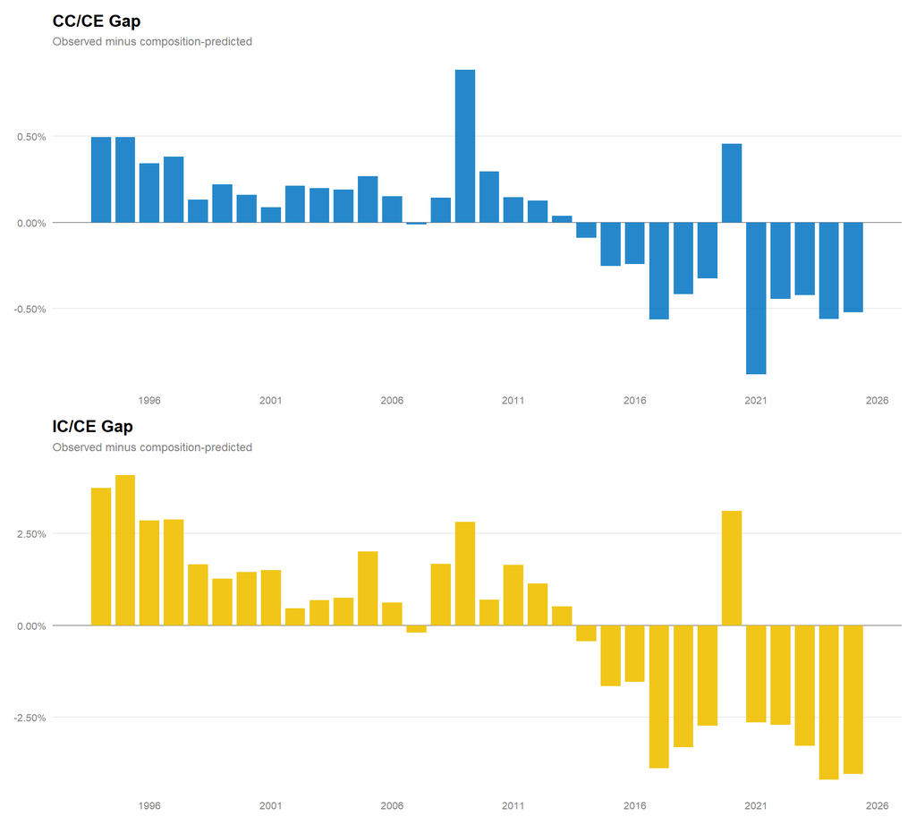

Figure 20: Annual gap between observed and composition-predicted claims intensity. Persistent negative gaps indicate the composition model overpredicts—observed intensity is lower than the unemployment mix would imply.

```r
p_cc_annual_gap <- ggplot(annual_gap_summary, aes(date, cc_ce_gap)) +
  geom_hline(yintercept = 0, color = "grey60", linewidth = 0.5) +
  geom_col(fill = "#0073C2", alpha = 0.85, width = 300) +
  scale_y_continuous(labels = percent_format(accuracy = 0.01)) +
  scale_x_date(date_breaks = "5 years", date_labels = "%Y") +
  labs(title = "CC/CE Gap", subtitle = "Observed minus composition-predicted", x = NULL, y = NULL)

p_ic_annual_gap <- ggplot(annual_gap_summary, aes(date, ic_ce_gap)) +
  geom_hline(yintercept = 0, color = "grey60", linewidth = 0.5) +
  geom_col(fill = "#EFC000", alpha = 0.9, width = 300) +
  scale_y_continuous(labels = percent_format(accuracy = 0.01)) +
  scale_x_date(date_breaks = "5 years", date_labels = "%Y") +
  labs(title = "IC/CE Gap", subtitle = "Observed minus composition-predicted", x = NULL, y = NULL)

p_cc_annual_gap / p_ic_annual_gap
```

### Comparison: National Aggregate vs. State Panel

The state-panel gap above uses CPS-based state-level composition and absorbs cross-state level differences via state fixed effects. To isolate how much the state FE and CPS measurement contribute, I collapse the state panel to a single national annual series (population-weighted means) and estimate the same by-cause OLS without fixed effects. The resulting gap is directly comparable to the national annual gap in Section 7.2, but uses CPS-derived shares rather than FRED aggregates.

```r
national_from_panel <- panel_year |>
  group_by(year) |>
  summarise(
    cc_ce = weighted.mean(continued_claims_per_covered_employment, annual_population, na.rm = TRUE),
    ic_ce = weighted.mean(initial_claims_per_covered_employment, annual_population, na.rm = TRUE),
    temp_layoff_share    = weighted.mean(temp_layoff_share,    annual_population, na.rm = TRUE),
    perm_job_loser_share = weighted.mean(perm_job_loser_share, annual_population, na.rm = TRUE),
    job_leaver_share     = weighted.mean(job_leaver_share,     annual_population, na.rm = TRUE),
    reentrant_share      = weighted.mean(reentrant_share,      annual_population, na.rm = TRUE),
    new_entrant_share    = weighted.mean(new_entrant_share,    annual_population, na.rm = TRUE),
    .groups = "drop"
  ) |>
  mutate(date = as.Date(paste0(year, "-01-01")))

collapsed_rhs <- "temp_layoff_share + perm_job_loser_share + job_leaver_share + reentrant_share + new_entrant_share"

cc_collapsed <- lm(as.formula(paste0("cc_ce ~ ", collapsed_rhs)), data = national_from_panel)
ic_collapsed <- lm(as.formula(paste0("ic_ce ~ ", collapsed_rhs)), data = national_from_panel)

national_from_panel <- national_from_panel |>
  mutate(
    cc_ce_hat = predict(cc_collapsed),
    ic_ce_hat = predict(ic_collapsed),
    cc_gap = cc_ce - cc_ce_hat,
    ic_gap = ic_ce - ic_ce_hat
  )
```

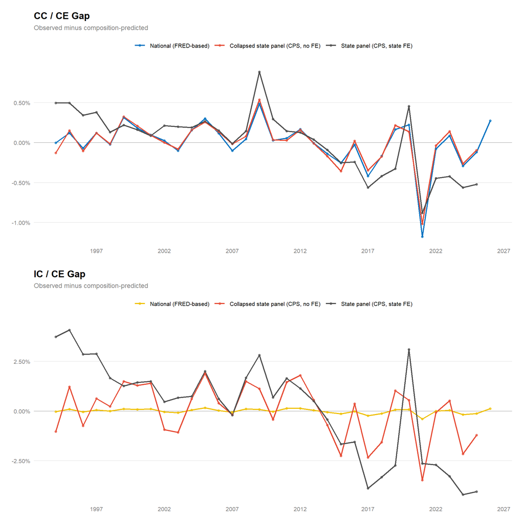

Figure 21: Annual composition gap: three approaches compared. (1) National FRED-based from Section 7.2, (2) collapsed state panel (CPS-based, no FE), (3) state panel with state FE. Differences between (1) and (2) reflect data source; differences between (2) and (3) reflect state fixed effects.

```r
gap_comparison <- bind_rows(
  national_annual |>
    transmute(date, cc_gap, ic_gap, source = "National (FRED-based)"),
  national_from_panel |>
    transmute(date, cc_gap, ic_gap, source = "Collapsed state panel (CPS, no FE)"),
  annual_gap_summary |>
    transmute(date, cc_gap = cc_ce_gap, ic_gap = ic_ce_gap, source = "State panel (CPS, state FE)")
) |>
  mutate(source = factor(source, levels = c(
    "National (FRED-based)",
    "Collapsed state panel (CPS, no FE)",
    "State panel (CPS, state FE)"
  )))

p_cc_compare <- ggplot(gap_comparison, aes(date, cc_gap, color = source)) +
  geom_hline(yintercept = 0, color = "grey60", linewidth = 0.3) +
  geom_line(linewidth = 0.8) +
  geom_point(size = 1.2, alpha = 0.7) +
  scale_color_manual(values = c("#0073C2", "#E64B35", "grey30")) +
  scale_y_continuous(labels = percent_format(accuracy = 0.01)) +
  scale_x_date(date_breaks = "5 years", date_labels = "%Y") +
  labs(title = "CC / CE Gap", subtitle = "Observed minus composition-predicted", x = NULL, y = NULL)

p_ic_compare <- ggplot(gap_comparison, aes(date, ic_gap, color = source)) +
  geom_hline(yintercept = 0, color = "grey60", linewidth = 0.3) +
  geom_line(linewidth = 0.8) +
  geom_point(size = 1.2, alpha = 0.7) +
  scale_color_manual(values = c("#EFC000", "#E64B35", "grey30")) +
  scale_y_continuous(labels = percent_format(accuracy = 0.01)) +
  scale_x_date(date_breaks = "5 years", date_labels = "%Y") +
  labs(title = "IC / CE Gap", subtitle = "Observed minus composition-predicted", x = NULL, y = NULL)

wrap_elements(p_cc_compare + theme(legend.position = "top")) /
  wrap_elements(p_ic_compare + theme(legend.position = "top"))
```

For IC/CE, the gaps are proportionally larger than for CC/CE. This is consistent with initial claims being a flow measure at the point of entry into the UI system, where the composition benchmark may have less predictive content relative to short-run administrative and institutional dynamics.

# 8. Interpretation

The results support a two-part conclusion.

**The composition benchmark has substantial reduced-form predictive content.** At the national level, by-cause unemployment shares and seasonality account for roughly 90% of the variation in CC/CE and 74% in IC/CE. Relative to completed temporary jobs, higher shares of job leavers and new entrants are associated with significantly lower claims intensity, consistent with these groups’ weaker UI attachment. In the state panel with both state and year fixed effects, the within $R^2$ drops sharply (roughly 0.09–0.14 for CC/CE, 0.04–0.05 for IC/CE), indicating that much of the raw predictive power of unemployment composition reflects persistent state differences and common national time movement rather than rich within-state identifying variation. This does not invalidate the composition benchmark; it clarifies that the benchmark’s value lies in tracking the aggregate evolution of claims intensity rather than in identifying sharp within-state effects. When year fixed effects are dropped and composition must account for the time path, the within $R^2$ rises substantially (0.71 for CC/CE, 0.67 for IC/CE), confirming that composition tracks the broad level and cyclical pattern of claims intensity under the historical reduced-form relationship.

The residual is *consistent with* several non-composition factors the literature has identified:

- **Administrative burden**: Parolin, Cross, and O’Brien (2023) document that burdens in UI have increased, disproportionately affecting minority families.
- **Employer deterrence**: Lachowska, Sorkin, and Woodbury (2025) show that firm effects on claiming are substantial, with high-appeal firms having lower claim rates.
- **Benefit generosity**: Anderson and Meyer (1997) established that the benefit elasticity of UI receipt is approximately 0.5; declining real generosity would reduce claiming.
- **State policy tightening**: Vroman (2018) documented that several states shortened maximum benefit durations and increased denial rates after the Great Recession.
- **Racial and demographic disparities**: Kuka and Stuart (2025) show persistent gaps in UI receipt by race that operate through claiming conditional on eligibility, not eligibility itself.
- **Information frictions and stigma**: Wandner and Stettner (2000) found that perceived ineligibility was the dominant reason for non-application among eligible workers.

This paper does not identify which of these channels dominates. The reduced-form design lacks the individual-level variation in eligibility, employer behavior, or administrative friction needed for that identification. What it does establish is the quantitative benchmark: how much of the variation in claims intensity is accounted for by the observable composition of unemployment under the historical reduced-form relationship, and therefore how large the residual is that mechanism-specific studies must collectively explain.

# 9. Conclusion

The composition of unemployment accounts for a meaningful share of the variation in UI claims intensity under the historical reduced-form relationship but does not fully account for the modern shortfall. The by-cause composition of unemployment—particularly the shares of job leavers and new entrants relative to the near-neutral completed-temp-job category—tracks the broad level and cyclical pattern of claims intensity at the national level and in state-panel models where within-state and within-year fixed effects absorb the aggregate confounds that a single national time series cannot isolate. The remaining gap is substantial, has turned persistently negative since roughly 2014, and has widened through 2024–2025.

This paper provides a composition-based benchmark for UI claims intensity and shows that recent claims intensity falls below the level historically associated with the realized unemployment mix. The literature has long recognized that job losers are more UI-relevant than new entrants, but it has not systematically estimated how much reduced-form explanatory leverage that compositional fact provides in a panel setting. The answer is: substantial, but not sufficient. The unexplained residual is large and growing, indicating that a complete account of low UI claims intensity requires understanding both the composition of the unemployment pool and the non-composition factors that shape claiming behavior.

The value of the composition benchmark rests on its institutional content, not on fit alone. Reason-for-unemployment categories are not data-mined predictors; they map directly onto the eligibility architecture of the UI system, giving the benchmark a clear interpretation that generic macro covariates would lack. Other variable sets that comove with the same cyclical and secular forces could also track the national time path reasonably well, but they would not answer the question the benchmark is designed to address: how much of the observed path of claims intensity is consistent with shifts in who becomes unemployed and how close those individuals are to the UI system’s historically intended beneficiaries? The composition benchmark is useful not because it is the only variable set that could fit the data, but because it is the one whose fit has direct institutional content.

Three implications follow. First, the by-cause unemployment mix offers a conceptually principled and empirically useful benchmark for UI claims intensity—one grounded in the structure of the program itself. Second, the residual gap between observed and composition-predicted claims intensity quantifies the target that institutional, administrative, and behavioral explanations must collectively account for. Third, the composition channel is likely to become more important as the structure of the labor market continues to evolve, with shifts in occupational mix, gig employment, and immigration patterns all affecting who shows up in the unemployment count and how close they are to the UI system’s originally intended beneficiaries.